# Passive Membrane Properties of Dorsal Horn Neurons

Anastasia Lysenko

## Introduction

### Hide Data

There are many diseases or injuries affecting the central nervous system (e.g. Alzheimer’s disease, Parkinson’s disease, traumatic injury) that afflict millions of people throughout the globe. There has been a lot of progress done in the past to better combat these afflictions. Yet, a lot is still unclear. One step forward is classifying and characterizing different neurons in the brain and the spinal cord. A cell’s electrical properties are directly derived from the electrical properties of its membrane. Thus, this project will involve analysis of passive membrane properties (resistance and capacitance) as well as resting potential which will help in the classification of different neuron cells into groups with similar properties.

These parameters will be determined from whole-cell patch-clamp recordings in current-clamp mode with zero input current and in voltage-clamp mode. The analysis could be done on currents induced by a brief voltage step.

All in all, the aim of this project is to test this approach for calculating passive membrane parameters from electrophysiological recordings and use them to characterize dorsal horn neurons from laminae I and II of the spinal cord.

The following document seeks to answer a question if light stimulation of RVM descendaing fibers changes passive membrane properties: membrane resistance($R_m$) and membrane capacitance($C_m$).

### Show Data

These results come from 2 adult mice which had 50 nl of ChR2 and YFP-producing viruses injected for 8 weeks. Axon Instruments electrophysiological equipment was used to record lamina I neuron cells’ responses from the Lumbar (L1–6) area of the spinal cord in the whole-cell patch-clamp mode. Optogenetic techniques (with monochromator) were applied for the activation of RVM descending axons. Total of 8 cells were successfully patched and had the data recorded on them.

```r
datatable(results)
```

|  | file | peak | plato | Ra | Rm+Ra | Rm | tau | Cm | Ih | Cell | Stimulation_Type | VC |
| --- | --- | --- | --- | --- | --- | --- | --- | --- | --- | --- | --- | --- |
| 1 | 2020_02_13_0000 | -337.6319275 | -42.69101334 | 29.61805204 | 234.241336 | 204.623284 | 0.308941841 | 1.509807853 | 150.2105408 | 1 | control | -10 |
| 2 | 2020_02_13_0000 | -337.9321594 | -37.43323135 | 29.59173823 | 267.1423128 | 237.5505746 | 0.337508887 | 1.4207875 | 121.2714691 | 1 | control | -10 |
| 3 | 2020_02_13_0000 | -334.2667542 | -40.65335083 | 29.91622671 | 245.9821834 | 216.0659567 | 0.365314752 | 1.690755719 | 106.8414459 | 1 | control | -10 |
| 4 | 2020_02_13_0000 | -322.5341492 | -33.38394165 | 31.00446891 | 299.5452156 | 268.5407467 | 0.317153513 | 1.181025663 | 100.4554443 | 1 | control | -10 |
| 5 | 2020_02_13_0000 | -325.8511658 | -29.47973251 | 30.68885752 | 339.2161037 | 308.5272461 | 0.322646081 | 1.045762037 | 99.50927734 | 1 | control | -10 |
| 6 | 2020_02_13_0000 | -320.9894714 | -30.11119652 | 31.15366979 | 332.1023791 | 300.9487093 | 0.332927316 | 1.106259327 | 90.50647736 | 1 | control | -10 |
| 7 | 2020_02_13_0000 | -326.1824036 | -30.26491737 | 30.65769303 | 330.4155725 | 299.7578794 | 0.343033224 | 1.144367664 | 87.8026886 | 1 | control | -10 |
| 8 | 2020_02_13_0000 | -309.3432922 | -21.51678658 | 32.32654546 | 464.7534131 | 432.4268676 | 0.387819052 | 0.896843098 | 78.87238312 | 1 | control | -10 |
| 9 | 2020_02_13_0000 | -317.0970764 | -36.25908661 | 31.53608388 | 275.7929373 | 244.2568534 | 0.350610852 | 1.435418689 | 67.83554077 | 1 | control | -10 |
| 10 | 2020_02_13_0000 | -311.3063354 | -36.82743454 | 32.12269993 | 271.5366988 | 239.4139989 | 0.343214959 | 1.433562618 | 71.40598297 | 1 | control | -10 |

[output cut: 630 more lines]

## Initial Analysis

### $R_m$

$$H_0: \mu_{control} = \mu_{monochromator}$$

$$H_a: \mu_{control} \neq \mu_{monochromator}$$

where,

$\mu_{control}$ is the mean membrane resistance value $R_m$ of the patched cell’s response after the axons of RVM were electrically stimulated (in $MΩ$);

$\mu_{monochromator}$ is the mean membrane resistance value $R_m$ of the patched cell’s response after the axons of RVM were simultaneously stimulated electrically and with a monochromator (in $MΩ$).

The level of significance is set at $\alpha$ = 0.05 for this study.

#### Summary of all Cells together

[figure not shown]

```r
# library
library(ggplot2)
ylim1 = c(0, 1200)

results$Cell <- as.factor(results$Cell)
results_color <- results %>%
  mutate(
    Rmpvalue = case_when(
           Cell == 1 ~ "high",
           Cell == 2 ~ "high",
           Cell == 3 ~ "low",
           Cell == 4 ~ "high",
           Cell == 5 ~ "high",
           Cell == 6 ~ "low",
           Cell == 7 ~ "high",
           Cell == 8 ~ "low")
  )


results_color <- results_color %>%
     mutate(
         colorgroup = case_when(
           Stimulation_Type == "control" & Rmpvalue == "high" ~ "gray58",
           Stimulation_Type == "monochromator" & Rmpvalue == "high" ~ "gray82",
           Stimulation_Type == "control" & Rmpvalue == "low" ~ "skyblue",
           Stimulation_Type == "monochromator" & Rmpvalue == "low" ~ "orange"
          )
        )

legend_title <- "Stimulation Type"


ggplot(results_color, aes(x=Cell, y=Rm, fill=colorgroup)) +
  geom_boxplot()+
  theme_light()+
  coord_cartesian(ylim = ylim1)+
  scale_fill_manual(legend_title,values = c("gray58", "gray82","skyblue","orange"), labels = c("non-signifcant control", "non-significant monochromator", "significant control", "significant monochromator"))+
  ggtitle("Optogenetically Stimulated vs Control\nAdult Mice Dorsal Horn Cells") +
  ylab(expression(R[m]~" (MOhm)")) +
  theme(legend.title=element_text(size=20), plot.title = element_text(size = 30, hjust = 0.5), axis.title=element_text(size=20), legend.text=element_text(size=14), axis.text.x = element_text(size = 14),  axis.text.y = element_text(size = 14))
```

```r
results %>%
group_by(Cell, Stimulation_Type)%>%
  summarise(min = min(Rm), Q1 = quantile(Rm, 0.25), med = median(Rm), Q3 = quantile(Rm, 0.75), max = max(Rm), mean=mean(Rm), sd =sd(Rm), 'sample size'=n()) %>% pander(caption="Summary Statistics of Rm of All Cells control vs Monochromator", split.table=Inf)
```

`summarise()` has grouped output by ‘Cell’. You can override using the `.groups` argument.

Summary Statistics of Rm of All Cells control vs Monochromator

| Cell | Stimulation_Type | min | Q1 | med | Q3 | max | mean | sd | sample size |
| --- | --- | --- | --- | --- | --- | --- | --- | --- | --- |
| 1 | control | 166.1 | 208.7 | 227.7 | 250.1 | 432.4 | 237.1 | 52.61 | 34 |
| 1 | monochromator | 178.4 | 220.5 | 229.5 | 241.5 | 330.6 | 232.2 | 31.01 | 25 |
| 2 | control | 354.8 | 832.1 | 923.7 | 1017 | 1446 | 907.4 | 162.1 | 59 |
| 2 | monochromator | 653.1 | 772.6 | 846.8 | 876.3 | 1072 | 846.1 | 110.8 | 20 |
| 3 | control | 136.5 | 236.9 | 248.4 | 261 | 337.6 | 247.6 | 24.84 | 70 |
| 3 | monochromator | 225.5 | 243.5 | 256.7 | 278.6 | 323.5 | 266.6 | 29.49 | 21 |
| 4 | control | 357.3 | 430.5 | 470.1 | 498.8 | 774.5 | 473.6 | 69.66 | 54 |
| 4 | monochromator | 262.1 | 430.8 | 460.2 | 503 | 689.8 | 473.2 | 93.34 | 32 |
| 5 | control | 497.9 | 529.1 | 554 | 573.3 | 589.7 | 548.7 | 32.57 | 10 |
| 5 | monochromator | 503.4 | 539.3 | 553.6 | 570.3 | 580.8 | 551.1 | 22.49 | 16 |
| 6 | control | 111.5 | 158.9 | 188.1 | 289 | 425.4 | 228.9 | 81.99 | 105 |
| 6 | monochromator | 126.8 | 173.4 | 249.7 | 285.7 | 461.1 | 236.8 | 67.79 | 63 |
| 7 | control | 118.2 | 231.1 | 318.9 | 435 | 3500 | 413.2 | 528.5 | 39 |
| 7 | monochromator | 121.3 | 309.9 | 370.7 | 450.7 | 2276 | 512.5 | 500.1 | 17 |
| 8 | control | 140 | 176.5 | 211 | 315 | 451.5 | 246.2 | 86.01 | 39 |
| 8 | monochromator | 105.7 | 184.2 | 267.5 | 289 | 498.4 | 249.5 | 82.15 | 36 |

#### Summary of each Cell individually

##### Cell 1

Below is the boxplot comparison of the $R_m$ values of the cell that was not stimulated by light (control) and the values when it was stimulated by light (monochromator):

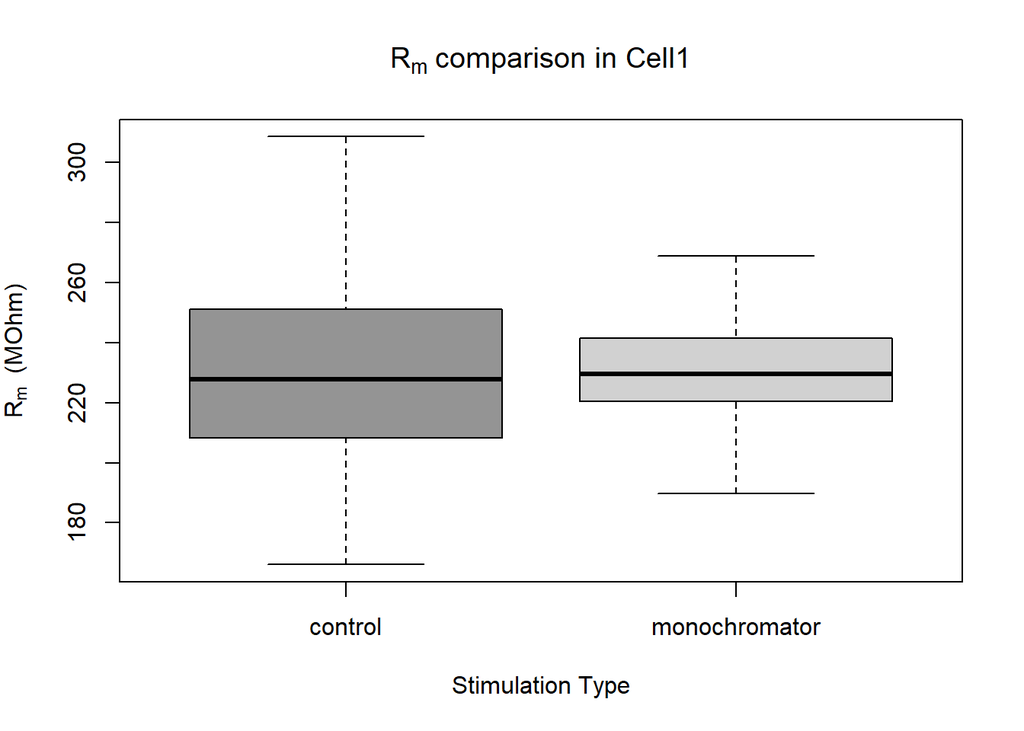

```r
cell1results <- filter(results, Cell == 1)

test <- t.test(Rm~Stimulation_Type, data = cell1results)
pvalue <- test[3]
if(pvalue < 0.05){
  pvalueis <- "significant"
  decision <- "we reject the null. This means that there is a significant"
  sign <- "<"
  color <-c("skyblue","orange")
} else {
  pvalueis <- "not significant"
  decision <- "we fail to reject the null. This means that there is no significant"
  sign <- ">"
  color <- c("gray58","gray82")
}


boxplot(Rm~Stimulation_Type, data = cell1results,outline=FALSE, col=color, main = c(expression(R[m]~"comparison in Cell1")), xlab ="Stimulation Type", ylab=c(expression(R[m]~" (MOhm)")))
```

```r
cell1results %>%
group_by(Stimulation_Type) %>%
  summarise(min = min(Rm), Q1 = quantile(Rm, 0.25), med = median(Rm), Q3 = quantile(Rm, 0.75), max = max(Rm), mean=mean(Rm), sd =sd(Rm), 'sample size'=n()) %>% pander(caption="Summary Statistics of Rm Cell1", split.table=Inf)
```

Summary Statistics of Rm Cell1

| Stimulation_Type | min | Q1 | med | Q3 | max | mean | sd | sample size |
| --- | --- | --- | --- | --- | --- | --- | --- | --- |
| control | 166.1 | 208.7 | 227.7 | 250.1 | 432.4 | 237.1 | 52.61 | 34 |
| monochromator | 178.4 | 220.5 | 229.5 | 241.5 | 330.6 | 232.2 | 31.01 | 25 |

Show the diagnostic plots(click to view)

Here are the results of the Independent Samples t Test we get:

```r
pander(t.test(Rm~Stimulation_Type, data = cell1results), split.table=Inf)
```

Welch Two Sample t-test: `Rm` by `Stimulation_Type`

| Test statistic | df | P value | Alternative hypothesis | mean in group control | mean in group monochromator |
| --- | --- | --- | --- | --- | --- |
| 0.4461 | 54.74 | 0.6573 | two.sided | 237.1 | 232.2 |

Since, our P-value is not significant ( 0.6572771 > $\alpha$), we fail to reject the null. This means that there is no significant evidence to conclude that when the axons of RVM are stimulated with monochromator membrane resistance of the cell changes significantly from that when there is no light stimulation.

##### Cell 2

Below is the boxplot comparison of the $R_m$ values of the cell that was not stimulated by light (control) and the values when it was stimulated by light (monochromator):

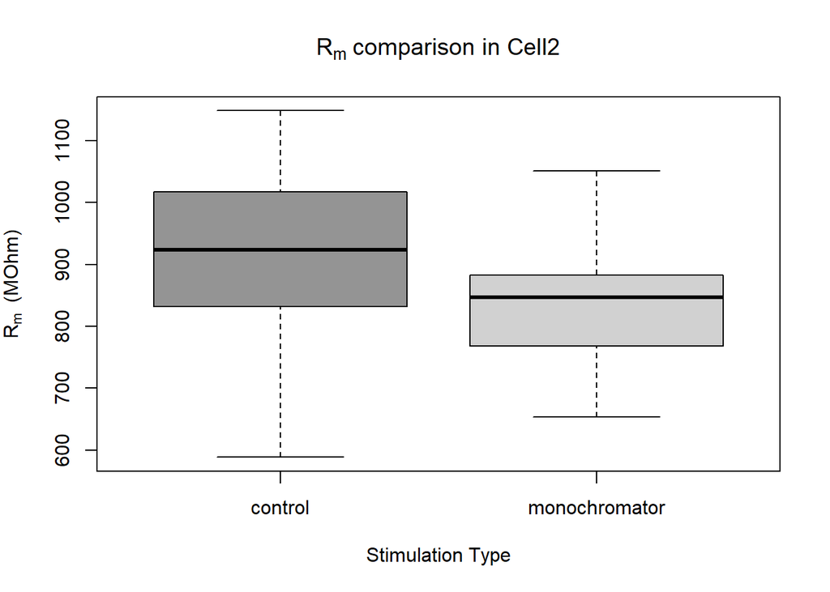

```r
cell2results <- filter(results, Cell == 2)

test <- t.test(Rm~Stimulation_Type, data = cell2results)
pvalue <- test[3]
if(pvalue < 0.05){
  pvalueis <- "significant"
  decision <- "we reject the null. This means that there is a significant"
  sign <- "<"
  color <-c("skyblue","orange")
} else {
  pvalueis <- "not significant"
  decision <- "we fail to reject the null. This means that there is no significant"
  sign <- ">"
  color <- c("gray58","gray82")
}

boxplot(Rm~Stimulation_Type, data = cell2results,outline=FALSE, col=color, main = c(expression(R[m]~"comparison in Cell2")), xlab ="Stimulation Type", ylab=c(expression(R[m]~" (MOhm)")))
```

```r
cell2results %>%
group_by(Stimulation_Type) %>%
  summarise(min = min(Rm), Q1 = quantile(Rm, 0.25), med = median(Rm), Q3 = quantile(Rm, 0.75), max = max(Rm), mean=mean(Rm), sd =sd(Rm), 'sample size'=n()) %>% pander(caption="Summary Statistics of Rm Cell2", split.table=Inf)
```

Summary Statistics of Rm Cell2

| Stimulation_Type | min | Q1 | med | Q3 | max | mean | sd | sample size |
| --- | --- | --- | --- | --- | --- | --- | --- | --- |
| control | 354.8 | 832.1 | 923.7 | 1017 | 1446 | 907.4 | 162.1 | 59 |
| monochromator | 653.1 | 772.6 | 846.8 | 876.3 | 1072 | 846.1 | 110.8 | 20 |

Show the diagnostic plots(click to view)

Here are the results we get:

```r
pander(t.test(Rm~Stimulation_Type, data = cell2results), split.table=Inf)
```

Welch Two Sample t-test: `Rm` by `Stimulation_Type`

| Test statistic | df | P value | Alternative hypothesis | mean in group control | mean in group monochromator |
| --- | --- | --- | --- | --- | --- |
| 1.885 | 48.27 | 0.06539 | two.sided | 907.4 | 846.1 |

Since, our P-value is not significant (0.0653941 > $\alpha$), we fail to reject the null. This means that there is no significant evidence to conclude that when the axons of RVM are stimulated with monochromator membrane resistance of the cell changes significantly from that when there is no light stimulation.

##### Cell 3

Below is the boxplot comparison of the $R_m$ values of the cell that was not stimulated by light (control) and the values when it was stimulated by light (monochromator):

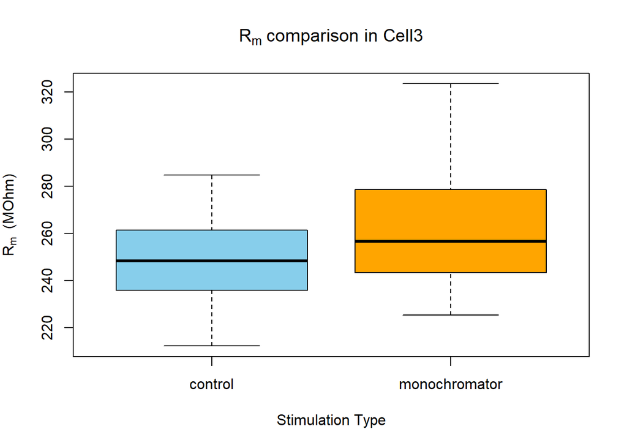

```r
cell3results <- filter(results, Cell == 3)

test <- t.test(Rm~Stimulation_Type, data = cell3results)
pvalue <- test[3]
if(pvalue < 0.05){
  pvalueis <- "significant"
  decision <- "we reject the null. This means that there is a significant"
  sign <- "<"
  color <-c("skyblue","orange")
} else {
  pvalueis <- "not significant"
  decision <- "we fail to reject the null. This means that there is no significant"
  sign <- ">"
  color <- c("gray58","gray82")
}

boxplot(Rm~Stimulation_Type, data = cell3results,outline=FALSE, col=color, main = c(expression(R[m]~"comparison in Cell3")), xlab ="Stimulation Type", ylab=c(expression(R[m]~" (MOhm)")))
```

```r
cell3results %>%
group_by(Stimulation_Type) %>%
  summarise(min = min(Rm), Q1 = quantile(Rm, 0.25), med = median(Rm), Q3 = quantile(Rm, 0.75), max = max(Rm), mean=mean(Rm), sd =sd(Rm), 'sample size'=n()) %>% pander(caption="Summary Statistics of Rm Cell2", split.table=Inf)
```

| Stimulation_Type | min | Q1 | med | Q3 | max | mean | sd | sample size |
| --- | --- | --- | --- | --- | --- | --- | --- | --- |
| control | 136.5 | 236.9 | 248.4 | 261 | 337.6 | 247.6 | 24.84 | 70 |
| monochromator | 225.5 | 243.5 | 256.7 | 278.6 | 323.5 | 266.6 | 29.49 | 21 |

Show the diagnostic plots(click to view)

Here are the results we get:

```r
pander(t.test(Rm~Stimulation_Type, data = cell3results), split.table=Inf)
```

Welch Two Sample t-test: `Rm` by `Stimulation_Type`

| Test statistic | df | P value | Alternative hypothesis | mean in group control | mean in group monochromator |
| --- | --- | --- | --- | --- | --- |
| -2.686 | 29.04 | 0.01182 * | two.sided | 247.6 | 266.6 |

Since, our P-value is significant (0.0118229 < $\alpha$), we reject the null. This means that there is a significant evidence to conclude that when the axons of RVM are stimulated with monochromator membrane resistance of the cell changes significantly from that when there is no light stimulation.

##### Cell 4

Below is the boxplot comparison of the $R_m$ values of the cell that was not stimulated by light (control) and the values when it was stimulated by light (monochromator):

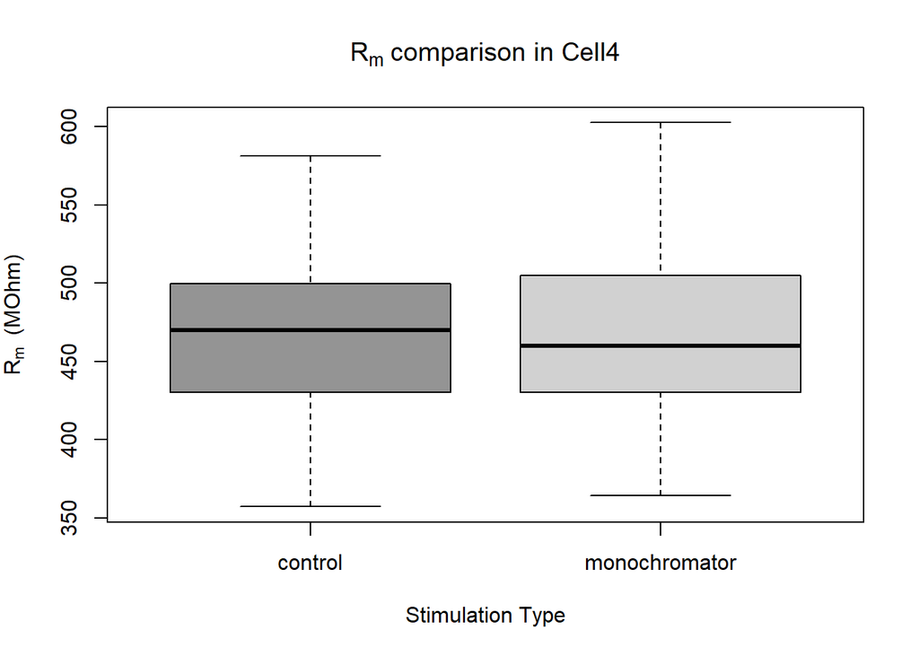

```r
cell4results <- filter(results, Cell == 4)

test <- t.test(Rm~Stimulation_Type, data = cell4results)
pvalue <- test[3]
if(pvalue < 0.05){
  pvalueis <- "significant"
  decision <- "we reject the null. This means that there is a significant"
  sign <- "<"
  color <-c("skyblue","orange")
} else {
  pvalueis <- "not significant"
  decision <- "we fail to reject the null. This means that there is no significant"
  sign <- ">"
  color <- c("gray58","gray82")
}

boxplot(Rm~Stimulation_Type, data = cell4results,outline=FALSE, col=color, main = c(expression(R[m]~"comparison in Cell4")), xlab ="Stimulation Type", ylab=c(expression(R[m]~" (MOhm)")))
```

```r
cell4results %>%
group_by(Stimulation_Type) %>%
  summarise(min = min(Rm), Q1 = quantile(Rm, 0.25), med = median(Rm), Q3 = quantile(Rm, 0.75), max = max(Rm), mean=mean(Rm), sd =sd(Rm), 'sample size'=n()) %>% pander(caption="Summary Statistics of Rm Cell2", split.table=Inf)
```

| Stimulation_Type | min | Q1 | med | Q3 | max | mean | sd | sample size |
| --- | --- | --- | --- | --- | --- | --- | --- | --- |
| control | 357.3 | 430.5 | 470.1 | 498.8 | 774.5 | 473.6 | 69.66 | 54 |
| monochromator | 262.1 | 430.8 | 460.2 | 503 | 689.8 | 473.2 | 93.34 | 32 |

Show the diagnostic plots(click to view)

Here are the results we get:

```r
pander(t.test(Rm~Stimulation_Type, data = cell4results), split.table=Inf)
```

Welch Two Sample t-test: `Rm` by `Stimulation_Type`

| Test statistic | df | P value | Alternative hypothesis | mean in group control | mean in group monochromator |
| --- | --- | --- | --- | --- | --- |
| 0.02405 | 51.56 | 0.9809 | two.sided | 473.6 | 473.2 |

Since, our P-value is not significant (0.9809052 > $\alpha$), we fail to reject the null. This means that there is no significant evidence to conclude that when the axons of RVM are stimulated with monochromator membrane resistance of the cell changes significantly from that when there is no light stimulation.

##### Cell 5

Below is the boxplot comparison of the $R_m$ values of the cell that was not stimulated by light (control) and the values when it was stimulated by light (monochromator):

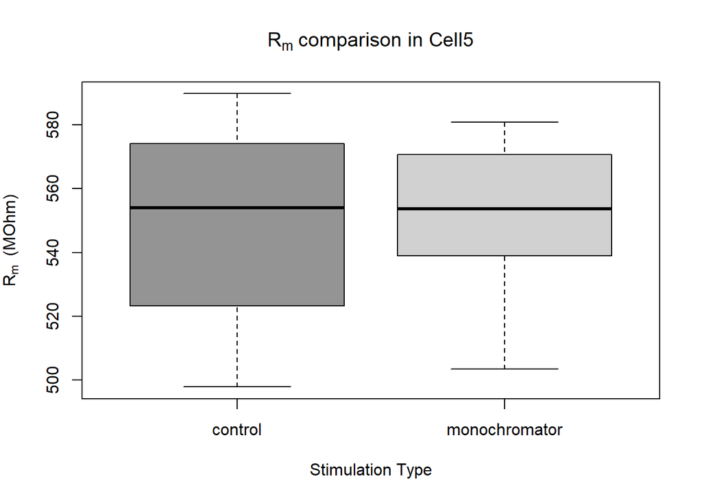

```r
cell5results <- filter(results, Cell == 5)

test <- t.test(Rm~Stimulation_Type, data = cell5results)
pvalue <- test[3]
if(pvalue < 0.05){
  pvalueis <- "significant"
  decision <- "we reject the null. This means that there is a significant"
  sign <- "<"
  color <-c("skyblue","orange")
} else {
  pvalueis <- "not significant"
  decision <- "we fail to reject the null. This means that there is no significant"
  sign <- ">"
  color <- c("gray58","gray82")
}

boxplot(Rm~Stimulation_Type, data = cell5results,outline=FALSE, col=color, main = c(expression(R[m]~"comparison in Cell5")), xlab ="Stimulation Type", ylab=c(expression(R[m]~" (MOhm)")))
```

```r
cell5results %>%
group_by(Stimulation_Type) %>%
  summarise(min = min(Rm), Q1 = quantile(Rm, 0.25), med = median(Rm), Q3 = quantile(Rm, 0.75), max = max(Rm), mean=mean(Rm), sd =sd(Rm), 'sample size'=n()) %>% pander(caption="Summary Statistics of Rm Cell2", split.table=Inf)
```

| Stimulation_Type | min | Q1 | med | Q3 | max | mean | sd | sample size |
| --- | --- | --- | --- | --- | --- | --- | --- | --- |
| control | 497.9 | 529.1 | 554 | 573.3 | 589.7 | 548.7 | 32.57 | 10 |
| monochromator | 503.4 | 539.3 | 553.6 | 570.3 | 580.8 | 551.1 | 22.49 | 16 |

Show the diagnostic plots(click to view)

Here are the results we get:

```r
pander(t.test(Rm~Stimulation_Type, data = cell5results), split.table=Inf)
```

Welch Two Sample t-test: `Rm` by `Stimulation_Type`

| Test statistic | df | P value | Alternative hypothesis | mean in group control | mean in group monochromator |
| --- | --- | --- | --- | --- | --- |
| -0.2043 | 14.39 | 0.841 | two.sided | 548.7 | 551.1 |

Since, our P-value is not significant (0.8409725 > $\alpha$), we fail to reject the null. This means that there is no significant evidence to conclude that when the axons of RVM are stimulated with monochromator membrane resistance of the cell changes significantly from that when there is no light stimulation.

##### Cell 6

###### VC = -10

Below is the boxplot comparison of the $R_m$ values of the cell that was not stimulated by light (control) and the values when it was stimulated by light (monochromator):

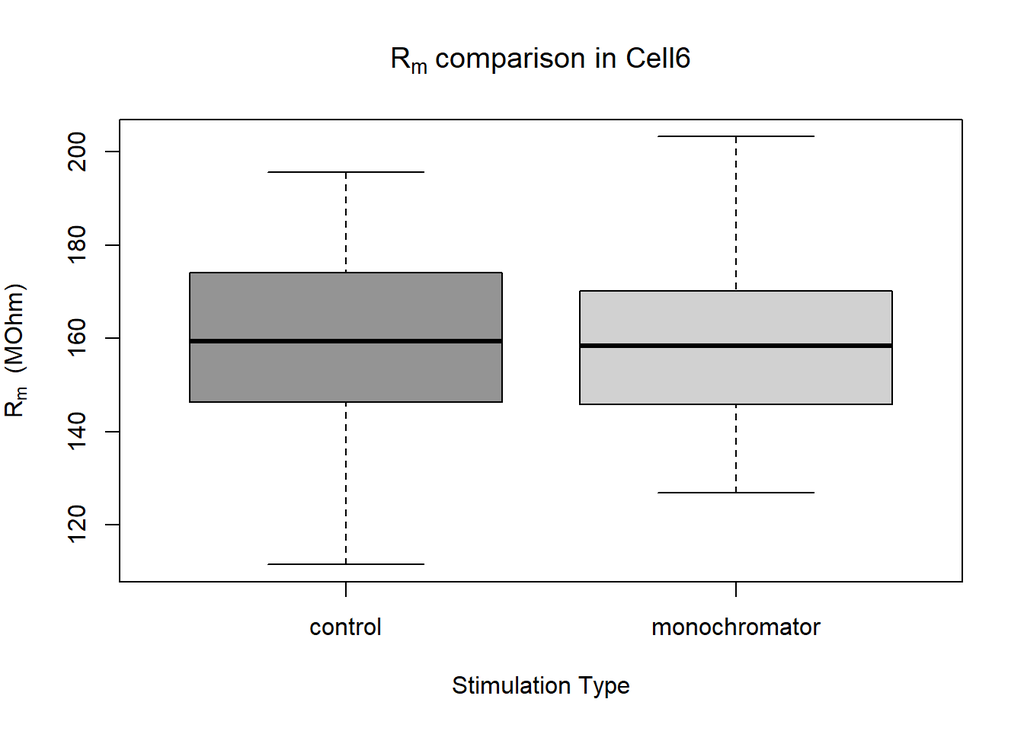

```r
cell6results_10 <- filter(results, Cell == 6 & VC == -10)

test <- t.test(Rm~Stimulation_Type, data = cell6results_10)
pvalue <- test[3]
if(pvalue < 0.05){
  pvalueis <- "significant"
  decision <- "we reject the null. This means that there is a significant"
  sign <- "<"
  color <-c("skyblue","orange")
} else {
  pvalueis <- "not significant"
  decision <- "we fail to reject the null. This means that there is no significant"
  sign <- ">"
  color <- c("gray58","gray82")
}

boxplot(Rm~Stimulation_Type, data = cell6results_10,outline=FALSE, col=color, main = c(expression(R[m]~"comparison in Cell6")), xlab ="Stimulation Type", ylab=c(expression(R[m]~" (MOhm)")))
```

```r
cell6results_10 %>%
group_by(Stimulation_Type) %>%
  summarise(min = min(Rm), Q1 = quantile(Rm, 0.25), med = median(Rm), Q3 = quantile(Rm, 0.75), max = max(Rm), mean=mean(Rm), sd =sd(Rm), 'sample size'=n()) %>% pander(caption="Summary Statistics of Rm Cell2", split.table=Inf)
```

| Stimulation_Type | min | Q1 | med | Q3 | max | mean | sd | sample size |
| --- | --- | --- | --- | --- | --- | --- | --- | --- |
| control | 111.5 | 146.3 | 159.3 | 173.9 | 195.7 | 160.1 | 18.21 | 54 |
| monochromator | 126.8 | 145.8 | 158.4 | 170.2 | 209.8 | 160.5 | 22.46 | 19 |

Show the diagnostic plots(click to view)

Here are the results we get:

```r
pander(t.test(Rm~Stimulation_Type, data = cell6results_10), split.table=Inf)
```

Welch Two Sample t-test: `Rm` by `Stimulation_Type`

| Test statistic | df | P value | Alternative hypothesis | mean in group control | mean in group monochromator |
| --- | --- | --- | --- | --- | --- |
| -0.08173 | 26.8 | 0.9355 | two.sided | 160.1 | 160.5 |

Since, our P-value is not significant (0.9354678 > $\alpha$), we fail to reject the null. This means that there is no significant evidence to conclude that when the axons of RVM are stimulated with monochromator membrane resistance of the cell changes significantly from that when there is no light stimulation.

###### VC = -60

Below is the boxplot comparison of the $R_m$ values of the cell that was not stimulated by light (control) and the values when it was stimulated by light (monochromator):

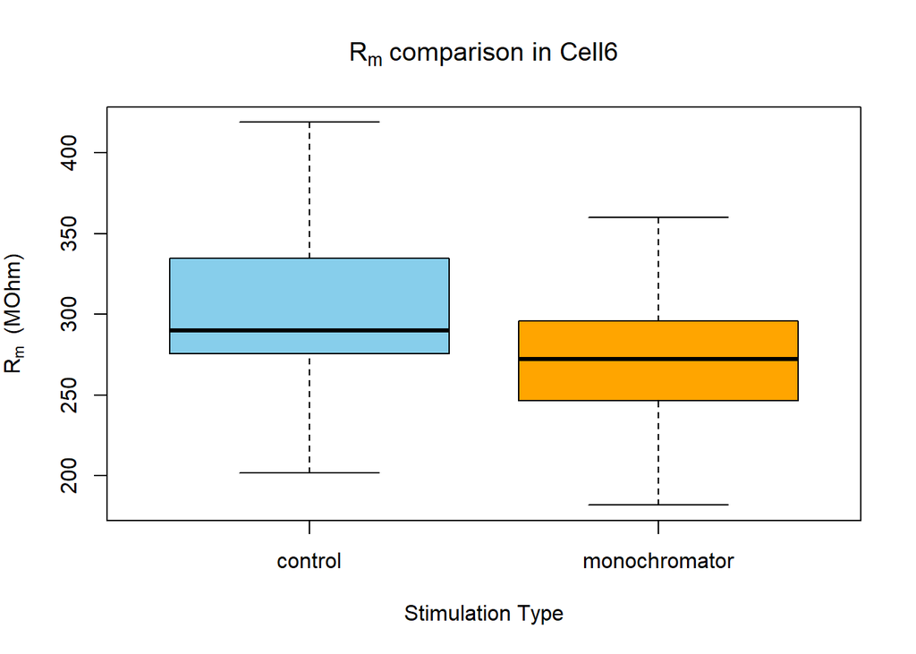

```r
cell6results_60 <- filter(results, Cell == 6 & VC == -60)

test <- t.test(Rm~Stimulation_Type, data = cell6results_60)
pvalue <- test[3]
if(pvalue < 0.05){
  pvalueis <- "significant"
  decision <- "we reject the null. This means that there is a significant"
  sign <- "<"
  color <-c("skyblue","orange")
} else {
  pvalueis <- "not significant"
  decision <- "we fail to reject the null. This means that there is no significant"
  sign <- ">"
  color <- c("gray58","gray82")
}

boxplot(Rm~Stimulation_Type, data = cell6results_60,outline=FALSE, col=color, main = c(expression(R[m]~"comparison in Cell6")), xlab ="Stimulation Type", ylab=c(expression(R[m]~" (MOhm)")))
```

```r
cell6results_60 %>%
group_by(Stimulation_Type) %>%
  summarise(min = min(Rm), Q1 = quantile(Rm, 0.25), med = median(Rm), Q3 = quantile(Rm, 0.75), max = max(Rm), mean=mean(Rm), sd =sd(Rm), 'sample size'=n()) %>% pander(caption="Summary Statistics of Rm Cell2", split.table=Inf)
```

| Stimulation_Type | min | Q1 | med | Q3 | max | mean | sd | sample size |
| --- | --- | --- | --- | --- | --- | --- | --- | --- |
| control | 132.9 | 275.7 | 289.8 | 334.5 | 425.4 | 301.8 | 55.6 | 51 |
| monochromator | 141 | 247.7 | 272.3 | 295.5 | 461.1 | 269.7 | 52.32 | 44 |

Show the diagnostic plots(click to view)

Here are the results we get:

```r
pander(t.test(Rm~Stimulation_Type, data = cell6results_60), split.table=Inf)
```

Welch Two Sample t-test: `Rm` by `Stimulation_Type`

| Test statistic | df | P value | Alternative hypothesis | mean in group control | mean in group monochromator |
| --- | --- | --- | --- | --- | --- |
| 2.898 | 92.28 | 0.004696 * * | two.sided | 301.8 | 269.7 |

Since, our P-value is significant (0.0046964 < $\alpha$), we reject the null. This means that there is a significant evidence to conclude that when the axons of RVM are stimulated with monochromator membrane resistance of the cell changes significantly from that when there is no light stimulation.

##### Cell 7

Below is the boxplot comparison of the $R_m$ values of the cell that was not stimulated by light (control) and the values when it was stimulated by light (monochromator):

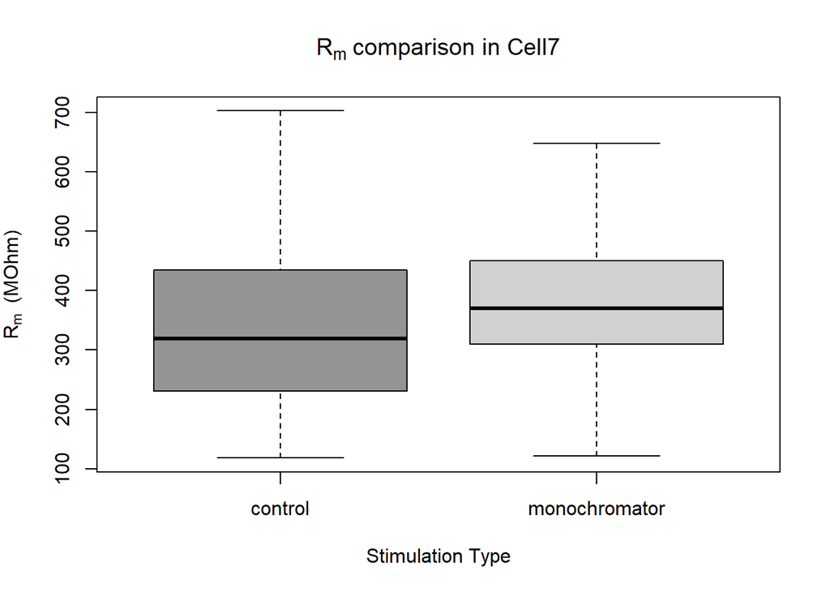

```r
cell7results <- filter(results, Cell == 7)

test <- t.test(Rm~Stimulation_Type, data = cell7results)
pvalue <- test[3]
if(pvalue < 0.05){
  pvalueis <- "significant"
  decision <- "we reject the null. This means that there is a significant"
  sign <- "<"
  color <-c("skyblue","orange")
} else {
  pvalueis <- "not significant"
  decision <- "we fail to reject the null. This means that there is no significant"
  sign <- ">"
  color <- c("gray58","gray82")
}

boxplot(Rm~Stimulation_Type, data = cell7results,outline=FALSE, col=color, main = c(expression(R[m]~"comparison in Cell7")), xlab ="Stimulation Type", ylab=c(expression(R[m]~" (MOhm)")))
```

```r
cell7results %>%
group_by(Stimulation_Type) %>%
  summarise(min = min(Rm), Q1 = quantile(Rm, 0.25), med = median(Rm), Q3 = quantile(Rm, 0.75), max = max(Rm), mean=mean(Rm), sd =sd(Rm), 'sample size'=n()) %>% pander(caption="Summary Statistics of Rm Cell2", split.table=Inf)
```

| Stimulation_Type | min | Q1 | med | Q3 | max | mean | sd | sample size |
| --- | --- | --- | --- | --- | --- | --- | --- | --- |
| control | 118.2 | 231.1 | 318.9 | 435 | 3500 | 413.2 | 528.5 | 39 |
| monochromator | 121.3 | 309.9 | 370.7 | 450.7 | 2276 | 512.5 | 500.1 | 17 |

Show the diagnostic plots(click to view)

Here are the results we get:

```r
pander(t.test(Rm~Stimulation_Type, data = cell7results), split.table=Inf)
```

Welch Two Sample t-test: `Rm` by `Stimulation_Type`

| Test statistic | df | P value | Alternative hypothesis | mean in group control | mean in group monochromator |
| --- | --- | --- | --- | --- | --- |
| -0.671 | 32.16 | 0.507 | two.sided | 413.2 | 512.5 |

Since, our P-value is not significant (0.5070314 > $\alpha$), we fail to reject the null. This means that there is no significant evidence to conclude that when the axons of RVM are stimulated with monochromator membrane resistance of the cell changes significantly from that when there is no light stimulation.

##### Cell 8

###### VC = -10

Below is the boxplot comparison of the $R_m$ values of the cell that was not stimulated by light (control) and the values when it was stimulated by light (monochromator):

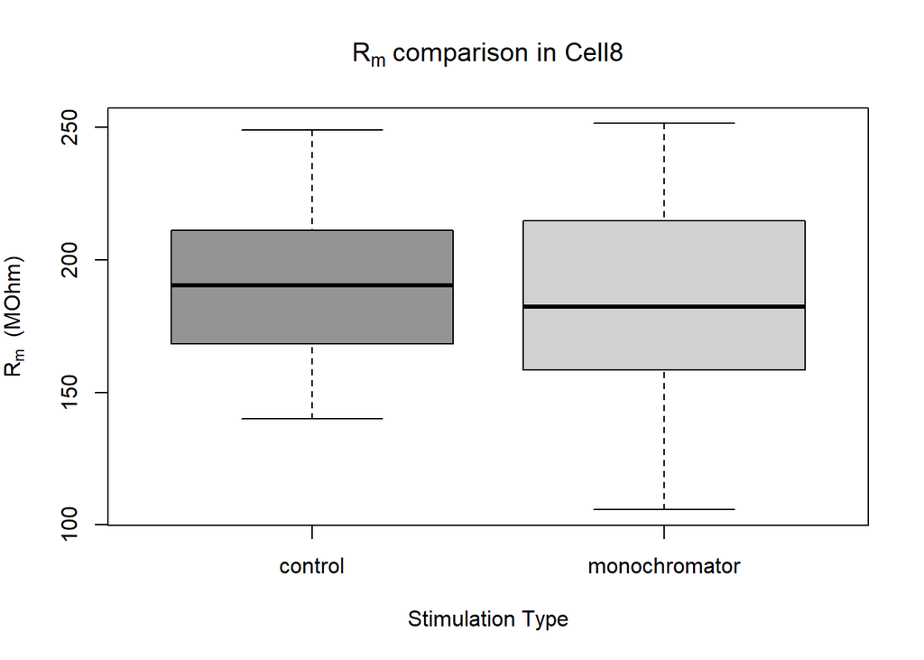

```r
cell8results_10 <- filter(results, Cell == 8 & VC == -10)

test <- t.test(Rm~Stimulation_Type, data = cell8results_10)
pvalue <- test[3]
if(pvalue < 0.05){
  pvalueis <- "significant"
  decision <- "we reject the null. This means that there is a significant"
  sign <- "<"
  color <-c("skyblue","orange")
} else {
  pvalueis <- "not significant"
  decision <- "we fail to reject the null. This means that there is no significant"
  sign <- ">"
  color <- c("gray58","gray82")
}

boxplot(Rm~Stimulation_Type, data = cell8results_10,outline=FALSE, col=color, main = c(expression(R[m]~"comparison in Cell8")), xlab ="Stimulation Type", ylab=c(expression(R[m]~" (MOhm)")))
```

```r
cell8results_10 %>%
group_by(Stimulation_Type) %>%
  summarise(min = min(Rm), Q1 = quantile(Rm, 0.25), med = median(Rm), Q3 = quantile(Rm, 0.75), max = max(Rm), mean=mean(Rm), sd =sd(Rm), 'sample size'=n()) %>% pander(caption="Summary Statistics of Rm Cell2", split.table=Inf)
```

| Stimulation_Type | min | Q1 | med | Q3 | max | mean | sd | sample size |
| --- | --- | --- | --- | --- | --- | --- | --- | --- |
| control | 140 | 168.4 | 190.3 | 210.5 | 248.9 | 192 | 29.76 | 26 |
| monochromator | 105.7 | 159 | 182.3 | 210.5 | 498.4 | 206.5 | 94.53 | 18 |

Show the diagnostic plots(click to view)

Here are the results we get:

```r
pander(t.test(Rm~Stimulation_Type, data = cell8results_10), split.table=Inf)
```

Welch Two Sample t-test: `Rm` by `Stimulation_Type`

| Test statistic | df | P value | Alternative hypothesis | mean in group control | mean in group monochromator |
| --- | --- | --- | --- | --- | --- |
| -0.6333 | 19.35 | 0.5339 | two.sided | 192 | 206.5 |

Since, our P-value is not significant (0.5339401 > $\alpha$), we fail to reject the null. This means that there is no significant evidence to conclude that when the axons of RVM are stimulated with monochromator membrane resistance of the cell changes significantly from that when there is no light stimulation.

###### VC = -60

Below is the boxplot comparison of the $R_m$ values of the cell that was not stimulated by light (control) and the values when it was stimulated by light (monochromator):

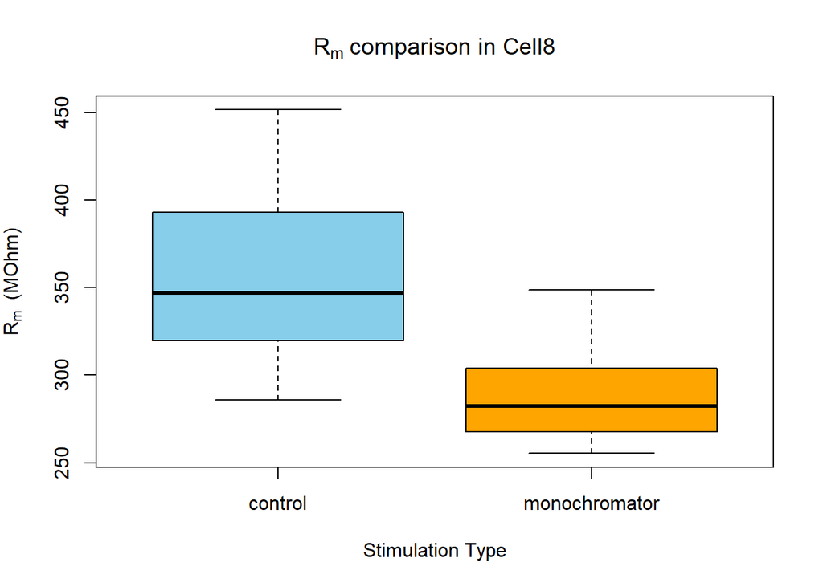

```r
cell8results_60 <- filter(results, Cell == 8 & VC == -60)

test <- t.test(Rm~Stimulation_Type, data = cell8results_60)
pvalue <- test[3]
if(pvalue < 0.05){
  pvalueis <- "significant"
  decision <- "we reject the null. This means that there is a significant"
  sign <- "<"
  color <-c("skyblue","orange")
} else {
  pvalueis <- "not significant"
  decision <- "we fail to reject the null. This means that there is no significant"
  sign <- ">"
  color <- c("gray58","gray82")
}

boxplot(Rm~Stimulation_Type, data = cell8results_60,outline=FALSE, col=color, main = c(expression(R[m]~"comparison in Cell8")), xlab ="Stimulation Type", ylab=c(expression(R[m]~" (MOhm)")))
```

```r
cell8results_60 %>%
group_by(Stimulation_Type) %>%
  summarise(min = min(Rm), Q1 = quantile(Rm, 0.25), med = median(Rm), Q3 = quantile(Rm, 0.75), max = max(Rm), mean=mean(Rm), sd =sd(Rm), 'sample size'=n()) %>% pander(caption="Summary Statistics of Rm Cell2", split.table=Inf)
```

| Stimulation_Type | min | Q1 | med | Q3 | max | mean | sd | sample size |
| --- | --- | --- | --- | --- | --- | --- | --- | --- |
| control | 285.7 | 319.6 | 347 | 393.1 | 451.5 | 354.7 | 49.63 | 13 |
| monochromator | 255.4 | 268 | 282.3 | 301.5 | 376 | 292.4 | 32.48 | 18 |

Show the diagnostic plots(click to view)

Here are the results we get:

```r
pander(t.test(Rm~Stimulation_Type, data = cell8results_60), split.table=Inf)
```

Welch Two Sample t-test: `Rm` by `Stimulation_Type`

| Test statistic | df | P value | Alternative hypothesis | mean in group control | mean in group monochromator |
| --- | --- | --- | --- | --- | --- |
| 3.953 | 19.27 | 0.0008332 * * * | two.sided | 354.7 | 292.4 |

Since, our P-value is significant (8.3325^{-4} < $\alpha$), we reject the null. This means that there is a significant evidence to conclude that when the axons of RVM are stimulated with monochromator membrane resistance of the cell changes significantly from that when there is no light stimulation.

### $C_m$

$$H_0: \mu_{control} = \mu_{monochromator}$$

$$H_a: \mu_{control} \neq \mu_{monochromator}$$

where,

$\mu_{control}$ is the mean membrane capacitance value $C_m$ of the patched cell’s response after the axons of RVM were electrically stimulated (in $pF$);

$\mu_{monochromator}$ is the mean membrane capacitance value $C_m$ of the patched cell’s response after the axons of RVM were simultaneously stimulated electrically and with a monochromator (in $pF$).

The level of significance is set at $\alpha$ = 0.05 for this study.

#### Summary of all Cells together

[figure not shown]

```r
# library
library(ggplot2)
ylim2 = c(0, 12)

results$Cell <- as.factor(results$Cell)
results_color <- results %>%
  mutate(
    Cmpvalue = case_when(
           Cell == 1 ~ "low",
           Cell == 2 ~ "low",
           Cell == 3 ~ "high",
           Cell == 4 ~ "high",
           Cell == 5 ~ "low",
           Cell == 6 ~ "low",
           Cell == 7 ~ "high",
           Cell == 8 ~ "low")
  )


results_color <- results_color %>%
     mutate(
         colorgroup_Cm = case_when(
           Stimulation_Type == "control" & Cmpvalue == "high" ~ "gray58",
           Stimulation_Type == "monochromator" & Cmpvalue == "high" ~ "gray82",
           Stimulation_Type == "control" & Cmpvalue == "low" ~ "skyblue",
           Stimulation_Type == "monochromator" & Cmpvalue == "low" ~ "orange"
          )
        )

legend_title <- "Stimulation Type"


ggplot(results_color, aes(x=Cell, y=Cm, fill=colorgroup_Cm)) +
  geom_boxplot()+
  theme_light()+
  coord_cartesian(ylim = ylim2)+
  scale_fill_manual(legend_title,values = c("gray58", "gray82","skyblue","orange"), labels = c("non-signifcant control", "non-significant monochromator", "significant control", "significant monochromator"))+
  ggtitle("Optogenetically Stimulated vs Control\nAdult Mice Dorsal Horn Cells") +
  ylab(expression(C[m]~" (pF)")) +
  theme(legend.title=element_text(size=20), plot.title = element_text(size = 30, hjust = 0.5), axis.title=element_text(size=20), legend.text=element_text(size=14), axis.text.x = element_text(size = 14),  axis.text.y = element_text(size = 14))
```

```r
results %>%
group_by(Cell, Stimulation_Type)%>%
  summarise(min = min(Cm), Q1 = quantile(Cm, 0.25), med = median(Cm), Q3 = quantile(Cm, 0.75), max = max(Cm), mean=mean(Cm), sd =sd(Cm), 'sample size'=n()) %>% pander(caption="Summary Statistics of Cm of All Cells control vs Monochromator", split.table=Inf)
```

`summarise()` has grouped output by ‘Cell’. You can override using the `.groups` argument.

Summary Statistics of Cm of All Cells control vs Monochromator

| Cell | Stimulation_Type | min | Q1 | med | Q3 | max | mean | sd | sample size |
| --- | --- | --- | --- | --- | --- | --- | --- | --- | --- |
| 1 | control | 0.8968 | 1.374 | 1.468 | 1.665 | 1.784 | 1.463 | 0.2258 | 34 |
| 1 | monochromator | 0.9734 | 1.467 | 1.581 | 1.816 | 2.103 | 1.625 | 0.265 | 25 |
| 2 | control | 0.2018 | 0.393 | 0.5371 | 0.6598 | 1.146 | 0.5272 | 0.2155 | 59 |
| 2 | monochromator | 0.5704 | 0.6623 | 0.7047 | 0.775 | 0.9235 | 0.7284 | 0.09291 | 20 |
| 3 | control | 1.993 | 3.183 | 3.595 | 4.009 | 8.419 | 3.602 | 0.9369 | 70 |
| 3 | monochromator | 1.536 | 2.192 | 5.024 | 5.739 | 6.673 | 4.154 | 1.847 | 21 |
| 4 | control | 1.202 | 1.693 | 2.721 | 3.084 | 3.953 | 2.532 | 0.7741 | 54 |
| 4 | monochromator | -16.82 | 1.903 | 2.43 | 3.169 | 5.453 | 2.029 | 3.548 | 32 |
| 5 | control | 0.9523 | 1.04 | 1.119 | 1.168 | 1.54 | 1.139 | 0.1614 | 10 |
| 5 | monochromator | 0.8441 | 0.875 | 0.8963 | 0.9345 | 1.032 | 0.9121 | 0.05494 | 16 |
| 6 | control | 2.388 | 3.946 | 4.457 | 5.375 | 8.391 | 4.748 | 1.308 | 105 |
| 6 | monochromator | 2.463 | 3.619 | 4.492 | 7.097 | 11 | 5.361 | 2.26 | 63 |
| 7 | control | 0.3176 | 1.728 | 2.124 | 3.294 | 6.68 | 2.656 | 1.513 | 39 |
| 7 | monochromator | 0.5014 | 2.379 | 2.792 | 3.98 | 8.797 | 3.49 | 2.269 | 17 |
| 8 | control | 3.462 | 4.411 | 5.757 | 6.73 | 9.849 | 5.881 | 1.766 | 39 |
| 8 | monochromator | 2.799 | 5.105 | 5.834 | 7.824 | 18.07 | 6.743 | 2.838 | 36 |

[figure not shown]

```r
# library
library(ggplot2)

results$Cell <- as.factor(results$Cell)

legend_title <- "Stimulation Type"


ggplot(results, aes(x=Cell, y=Cm, fill=Stimulation_Type)) +
  geom_boxplot()+
  theme_light()+
  coord_cartesian(ylim = ylim1)+
  scale_fill_manual(legend_title,values = c("skyblue","orange"))+
  ggtitle(c(expression(C[m]~"comparison of Control & Monochromator"))) +
  ylab(expression(C[m]~" (MOhm)")) +
  theme(legend.title=element_text(size=20), plot.title = element_text(size = 30), axis.title=element_text(size=20), legend.text=element_text(size=14))
```

```r
results %>%
group_by(Cell, Stimulation_Type)%>%
  summarise(min = min(Cm), Q1 = quantile(Cm, 0.25), med = median(Cm), Q3 = quantile(Cm, 0.75), max = max(Cm), mean=mean(Cm), sd =sd(Cm), 'sample size'=n()) %>% pander(caption="Summary Statistics of Cm of All Cells control vs Monochromator", split.table=Inf)
```

`summarise()` has grouped output by ‘Cell’. You can override using the `.groups` argument.

Summary Statistics of Cm of All Cells control vs Monochromator

| Cell | Stimulation_Type | min | Q1 | med | Q3 | max | mean | sd | sample size |
| --- | --- | --- | --- | --- | --- | --- | --- | --- | --- |
| 1 | control | 0.8968 | 1.374 | 1.468 | 1.665 | 1.784 | 1.463 | 0.2258 | 34 |
| 1 | monochromator | 0.9734 | 1.467 | 1.581 | 1.816 | 2.103 | 1.625 | 0.265 | 25 |
| 2 | control | 0.2018 | 0.393 | 0.5371 | 0.6598 | 1.146 | 0.5272 | 0.2155 | 59 |
| 2 | monochromator | 0.5704 | 0.6623 | 0.7047 | 0.775 | 0.9235 | 0.7284 | 0.09291 | 20 |
| 3 | control | 1.993 | 3.183 | 3.595 | 4.009 | 8.419 | 3.602 | 0.9369 | 70 |
| 3 | monochromator | 1.536 | 2.192 | 5.024 | 5.739 | 6.673 | 4.154 | 1.847 | 21 |
| 4 | control | 1.202 | 1.693 | 2.721 | 3.084 | 3.953 | 2.532 | 0.7741 | 54 |
| 4 | monochromator | -16.82 | 1.903 | 2.43 | 3.169 | 5.453 | 2.029 | 3.548 | 32 |
| 5 | control | 0.9523 | 1.04 | 1.119 | 1.168 | 1.54 | 1.139 | 0.1614 | 10 |
| 5 | monochromator | 0.8441 | 0.875 | 0.8963 | 0.9345 | 1.032 | 0.9121 | 0.05494 | 16 |
| 6 | control | 2.388 | 3.946 | 4.457 | 5.375 | 8.391 | 4.748 | 1.308 | 105 |
| 6 | monochromator | 2.463 | 3.619 | 4.492 | 7.097 | 11 | 5.361 | 2.26 | 63 |
| 7 | control | 0.3176 | 1.728 | 2.124 | 3.294 | 6.68 | 2.656 | 1.513 | 39 |
| 7 | monochromator | 0.5014 | 2.379 | 2.792 | 3.98 | 8.797 | 3.49 | 2.269 | 17 |
| 8 | control | 3.462 | 4.411 | 5.757 | 6.73 | 9.849 | 5.881 | 1.766 | 39 |
| 8 | monochromator | 2.799 | 5.105 | 5.834 | 7.824 | 18.07 | 6.743 | 2.838 | 36 |

#### Summary of each Cell individually

##### Cell 1

Below is the boxplot comparison of the $C_m$ values of the cell that was not stimulated by light (control) and the values when it was stimulated by light (monochromator):

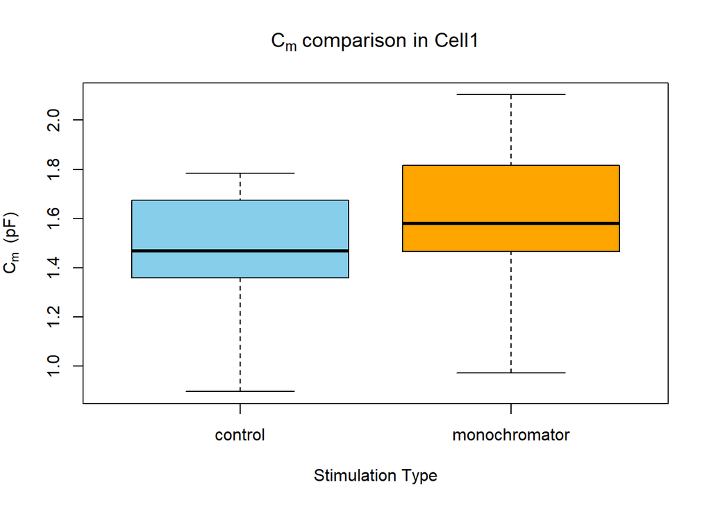

```r
test <- t.test(Cm~Stimulation_Type, data = cell1results)
pvalue <- test[3]
if(pvalue < 0.05){
  pvalueis <- "significant"
  decision <- "we reject the null. This means that there is a significant"
  sign <- "<"
  color <-c("skyblue","orange")
} else {
  pvalueis <- "not significant"
  decision <- "we fail to reject the null. This means that there is no significant"
  sign <- ">"
  color <- c("gray58","gray82")
}


boxplot(Cm~Stimulation_Type, data = cell1results,outline=FALSE, col=color, main = c(expression(C[m]~"comparison in Cell1")), xlab ="Stimulation Type", ylab=c(expression(C[m]~" (pF)")))
```

```r
cell1results %>%
group_by(Stimulation_Type) %>%
  summarise(min = min(Cm), Q1 = quantile(Cm, 0.25), med = median(Cm), Q3 = quantile(Cm, 0.75), max = max(Cm), mean=mean(Cm), sd =sd(Cm), 'sample size'=n()) %>% pander(caption="Summary Statistics of Cm Cell1", split.table=Inf)
```

Summary Statistics of Cm Cell1

| Stimulation_Type | min | Q1 | med | Q3 | max | mean | sd | sample size |
| --- | --- | --- | --- | --- | --- | --- | --- | --- |
| control | 0.8968 | 1.374 | 1.468 | 1.665 | 1.784 | 1.463 | 0.2258 | 34 |
| monochromator | 0.9734 | 1.467 | 1.581 | 1.816 | 2.103 | 1.625 | 0.265 | 25 |

Show the diagnostic plots(click to view)

Here are the results of the Independent Samples t Test we get:

```r
pander(t.test(Cm~Stimulation_Type, data = cell1results), split.table=Inf)
```

Welch Two Sample t-test: `Cm` by `Stimulation_Type`

| Test statistic | df | P value | Alternative hypothesis | mean in group control | mean in group monochromator |
| --- | --- | --- | --- | --- | --- |
| -2.47 | 46.77 | 0.01722 * | two.sided | 1.463 | 1.625 |

Since, our P-value is significant (0.0172217 < $\alpha$), we reject the null. This means that there is a significant evidence to conclude that when the axons of RVM are stimulated with monochromator membrane capacitance of the cell changes significantly from that when there is no light stimulation.

##### Cell 2

Below is the boxplot comparison of the $C_m$ values of the cell that was not stimulated by light (control) and the values when it was stimulated by light (monochromator):

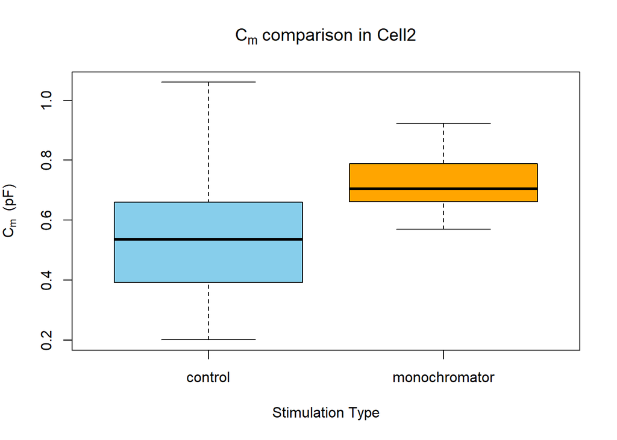

```r
test <- t.test(Cm~Stimulation_Type, data = cell2results)
pvalue <- test[3]
if(pvalue < 0.05){
  pvalueis <- "significant"
  decision <- "we reject the null. This means that there is a significant"
  sign <- "<"
  color <-c("skyblue","orange")
} else {
  pvalueis <- "not significant"
  decision <- "we fail to reject the null. This means that there is no significant"
  sign <- ">"
  color <- c("gray58","gray82")
}


boxplot(Cm~Stimulation_Type, data = cell2results,outline=FALSE, col=color, main = c(expression(C[m]~"comparison in Cell2")), xlab ="Stimulation Type", ylab=c(expression(C[m]~" (pF)")))
```

```r
cell2results %>%
group_by(Stimulation_Type) %>%
  summarise(min = min(Cm), Q1 = quantile(Cm, 0.25), med = median(Cm), Q3 = quantile(Cm, 0.75), max = max(Cm), mean=mean(Cm), sd =sd(Cm), 'sample size'=n()) %>% pander(caption="Summary Statistics of Cm Cell1", split.table=Inf)
```

| Stimulation_Type | min | Q1 | med | Q3 | max | mean | sd | sample size |
| --- | --- | --- | --- | --- | --- | --- | --- | --- |
| control | 0.2018 | 0.393 | 0.5371 | 0.6598 | 1.146 | 0.5272 | 0.2155 | 59 |
| monochromator | 0.5704 | 0.6623 | 0.7047 | 0.775 | 0.9235 | 0.7284 | 0.09291 | 20 |

Show the diagnostic plots(click to view)

Here are the results of the Independent Samples t Test we get:

```r
pander(t.test(Cm~Stimulation_Type, data = cell2results), split.table=Inf)
```

Welch Two Sample t-test: `Cm` by `Stimulation_Type`

| Test statistic | df | P value | Alternative hypothesis | mean in group control | mean in group monochromator |
| --- | --- | --- | --- | --- | --- |
| -5.763 | 72.51 | 1.872e-07 * * * | two.sided | 0.5272 | 0.7284 |

Since, our P-value is significant (1.8716794^{-7} < $\alpha$), we reject the null. This means that there is a significant evidence to conclude that when the axons of RVM are stimulated with monochromator membrane capacitance of the cell changes significantly from that when there is no light stimulation.

##### Cell 3

Below is the boxplot comparison of the $C_m$ values of the cell that was not stimulated by light (control) and the values when it was stimulated by light (monochromator):

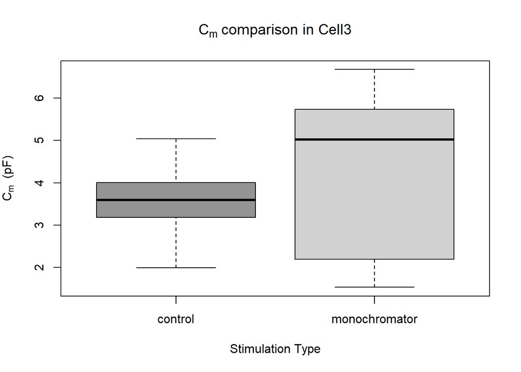

```r
test <- t.test(Cm~Stimulation_Type, data = cell3results)
pvalue <- test[3]
if(pvalue < 0.05){
  pvalueis <- "significant"
  decision <- "we reject the null. This means that there is a significant"
  sign <- "<"
  color <-c("skyblue","orange")
} else {
  pvalueis <- "not significant"
  decision <- "we fail to reject the null. This means that there is no significant"
  sign <- ">"
  color <- c("gray58","gray82")
}


boxplot(Cm~Stimulation_Type, data = cell3results,outline=FALSE, col=color, main = c(expression(C[m]~"comparison in Cell3")), xlab ="Stimulation Type", ylab=c(expression(C[m]~" (pF)")))
```

```r
cell3results %>%
group_by(Stimulation_Type) %>%
  summarise(min = min(Cm), Q1 = quantile(Cm, 0.25), med = median(Cm), Q3 = quantile(Cm, 0.75), max = max(Cm), mean=mean(Cm), sd =sd(Cm), 'sample size'=n()) %>% pander(caption="Summary Statistics of Cm Cell1", split.table=Inf)
```

| Stimulation_Type | min | Q1 | med | Q3 | max | mean | sd | sample size |
| --- | --- | --- | --- | --- | --- | --- | --- | --- |
| control | 1.993 | 3.183 | 3.595 | 4.009 | 8.419 | 3.602 | 0.9369 | 70 |
| monochromator | 1.536 | 2.192 | 5.024 | 5.739 | 6.673 | 4.154 | 1.847 | 21 |

Show the diagnostic plots(click to view)

Here are the results of the Independent Samples t Test we get:

```r
pander(t.test(Cm~Stimulation_Type, data = cell3results), split.table=Inf)
```

Welch Two Sample t-test: `Cm` by `Stimulation_Type`

| Test statistic | df | P value | Alternative hypothesis | mean in group control | mean in group monochromator |
| --- | --- | --- | --- | --- | --- |
| -1.32 | 23.17 | 0.1998 | two.sided | 3.602 | 4.154 |

Since, our P-value is not significant (0.1998297 > $\alpha$), we fail to reject the null. This means that there is no significant evidence to conclude that when the axons of RVM are stimulated with monochromator membrane capacitance of the cell changes significantly from that when there is no light stimulation.

##### Cell 4

Below is the boxplot comparison of the $C_m$ values of the cell that was not stimulated by light (control) and the values when it was stimulated by light (monochromator):

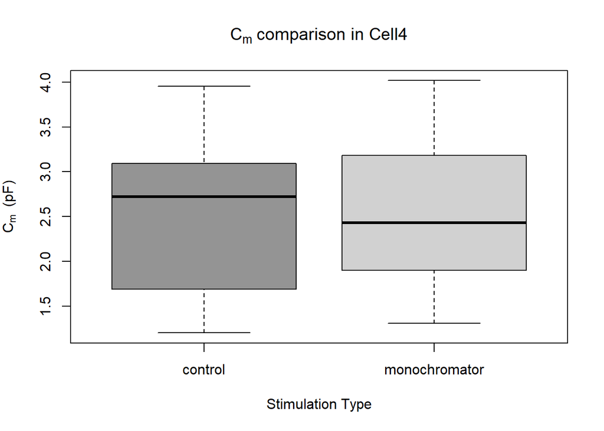

```r
test <- t.test(Cm~Stimulation_Type, data = cell4results)
pvalue <- test[3]
if(pvalue < 0.05){
  pvalueis <- "significant"
  decision <- "we reject the null. This means that there is a significant"
  sign <- "<"
  color <-c("skyblue","orange")
} else {
  pvalueis <- "not significant"
  decision <- "we fail to reject the null. This means that there is no significant"
  sign <- ">"
  color <- c("gray58","gray82")
}


boxplot(Cm~Stimulation_Type, data = cell4results,outline=FALSE, col=color, main = c(expression(C[m]~"comparison in Cell4")), xlab ="Stimulation Type", ylab=c(expression(C[m]~" (pF)")))
```

```r
cell4results %>%
group_by(Stimulation_Type) %>%
  summarise(min = min(Cm), Q1 = quantile(Cm, 0.25), med = median(Cm), Q3 = quantile(Cm, 0.75), max = max(Cm), mean=mean(Cm), sd =sd(Cm), 'sample size'=n()) %>% pander(caption="Summary Statistics of Cm Cell1", split.table=Inf)
```

| Stimulation_Type | min | Q1 | med | Q3 | max | mean | sd | sample size |
| --- | --- | --- | --- | --- | --- | --- | --- | --- |
| control | 1.202 | 1.693 | 2.721 | 3.084 | 3.953 | 2.532 | 0.7741 | 54 |
| monochromator | -16.82 | 1.903 | 2.43 | 3.169 | 5.453 | 2.029 | 3.548 | 32 |

Show the diagnostic plots(click to view)

Here are the results of the Independent Samples t Test we get:

```r
pander(t.test(Cm~Stimulation_Type, data = cell4results), split.table=Inf)
```

Welch Two Sample t-test: `Cm` by `Stimulation_Type`

| Test statistic | df | P value | Alternative hypothesis | mean in group control | mean in group monochromator |
| --- | --- | --- | --- | --- | --- |
| 0.7918 | 32.76 | 0.4342 | two.sided | 2.532 | 2.029 |

Since, our P-value is not significant (0.4342001 > $\alpha$), we fail to reject the null. This means that there is no significant evidence to conclude that when the axons of RVM are stimulated with monochromator membrane capacitance of the cell changes significantly from that when there is no light stimulation.

##### Cell 5

Below is the boxplot comparison of the $C_m$ values of the cell that was not stimulated by light (control) and the values when it was stimulated by light (monochromator):

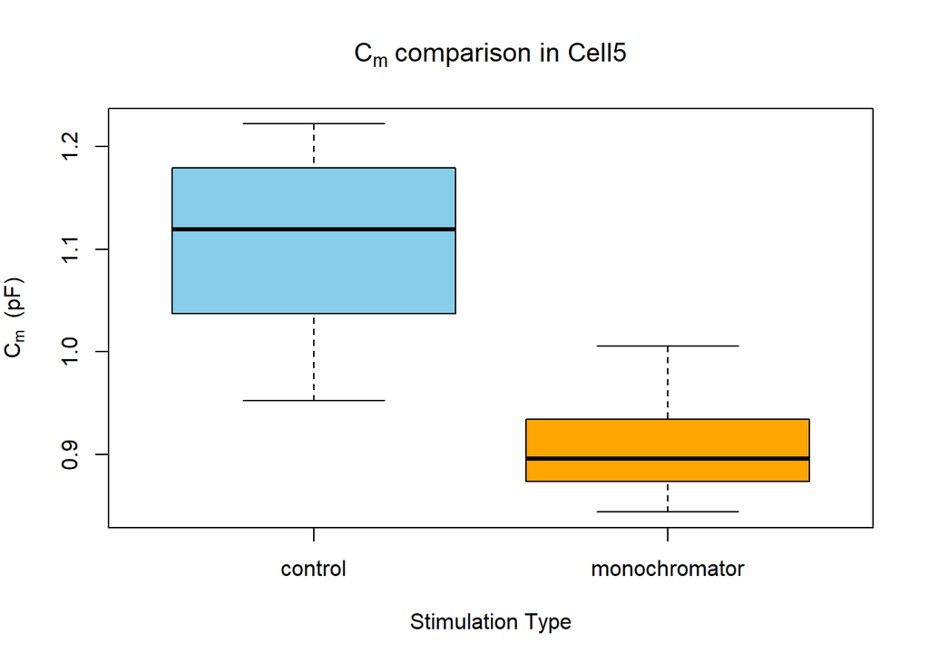

```r
test <- t.test(Cm~Stimulation_Type, data = cell5results)
pvalue <- test[3]
if(pvalue < 0.05){
  pvalueis <- "significant"
  decision <- "we reject the null. This means that there is a significant"
  sign <- "<"
  color <-c("skyblue","orange")
} else {
  pvalueis <- "not significant"
  decision <- "we fail to reject the null. This means that there is no significant"
  sign <- ">"
  color <- c("gray58","gray82")
}


boxplot(Cm~Stimulation_Type, data = cell5results,outline=FALSE, col=color, main = c(expression(C[m]~"comparison in Cell5")), xlab ="Stimulation Type", ylab=c(expression(C[m]~" (pF)")))
```

```r
cell5results %>%
group_by(Stimulation_Type) %>%
  summarise(min = min(Cm), Q1 = quantile(Cm, 0.25), med = median(Cm), Q3 = quantile(Cm, 0.75), max = max(Cm), mean=mean(Cm), sd =sd(Cm), 'sample size'=n()) %>% pander(caption="Summary Statistics of Cm Cell1", split.table=Inf)
```

| Stimulation_Type | min | Q1 | med | Q3 | max | mean | sd | sample size |
| --- | --- | --- | --- | --- | --- | --- | --- | --- |
| control | 0.9523 | 1.04 | 1.119 | 1.168 | 1.54 | 1.139 | 0.1614 | 10 |
| monochromator | 0.8441 | 0.875 | 0.8963 | 0.9345 | 1.032 | 0.9121 | 0.05494 | 16 |

Show the diagnostic plots(click to view)

Here are the results of the Independent Samples t Test we get:

```r
pander(t.test(Cm~Stimulation_Type, data = cell5results), split.table=Inf)
```

Welch Two Sample t-test: `Cm` by `Stimulation_Type`

| Test statistic | df | P value | Alternative hypothesis | mean in group control | mean in group monochromator |
| --- | --- | --- | --- | --- | --- |
| 4.286 | 10.32 | 0.001486 * * | two.sided | 1.139 | 0.9121 |

Since, our P-value is significant (0.0014856 < $\alpha$), we reject the null. This means that there is a significant evidence to conclude that when the axons of RVM are stimulated with monochromator membrane capacitance of the cell changes significantly from that when there is no light stimulation.

##### Cell 6

###### VC = -10

Below is the boxplot comparison of the $C_m$ values of the cell that was not stimulated by light (control) and the values when it was stimulated by light (monochromator):

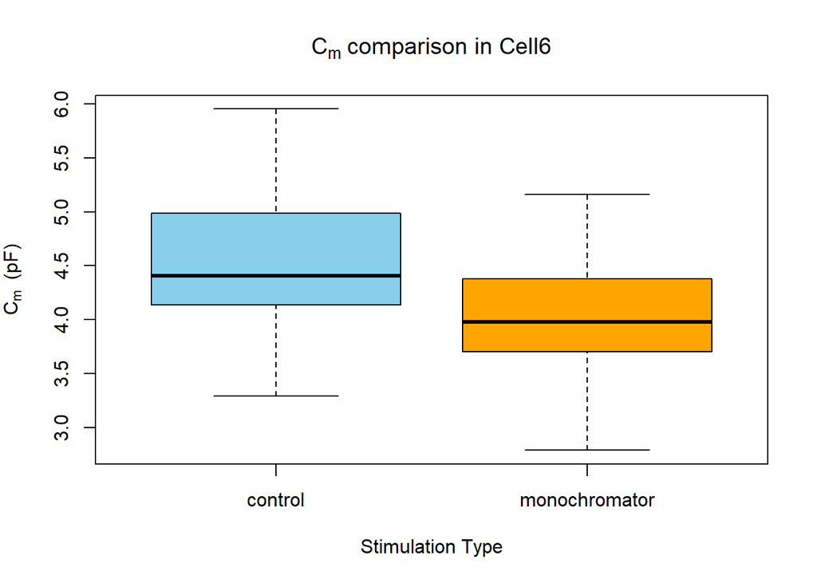

```r
test <- t.test(Cm~Stimulation_Type, data = cell6results_10)
pvalue <- test[3]
if(pvalue < 0.05){
  pvalueis <- "significant"
  decision <- "we reject the null. This means that there is a significant"
  sign <- "<"
  color <-c("skyblue","orange")
} else {
  pvalueis <- "not significant"
  decision <- "we fail to reject the null. This means that there is no significant"
  sign <- ">"
  color <- c("gray58","gray82")
}


boxplot(Cm~Stimulation_Type, data = cell6results_10,outline=FALSE, col=color, main = c(expression(C[m]~"comparison in Cell6")), xlab ="Stimulation Type", ylab=c(expression(C[m]~" (pF)")))
```

```r
cell6results_10 %>%
group_by(Stimulation_Type) %>%
  summarise(min = min(Cm), Q1 = quantile(Cm, 0.25), med = median(Cm), Q3 = quantile(Cm, 0.75), max = max(Cm), mean=mean(Cm), sd =sd(Cm), 'sample size'=n()) %>% pander(caption="Summary Statistics of Cm Cell1", split.table=Inf)
```

Summary Statistics of Cm Cell1

| Stimulation_Type | min | Q1 | med | Q3 | max | mean | sd | sample size |
| --- | --- | --- | --- | --- | --- | --- | --- | --- |
| control | 3.29 | 4.136 | 4.407 | 4.983 | 5.952 | 4.535 | 0.696 | 54 |
| monochromator | 2.79 | 3.704 | 3.979 | 4.379 | 5.158 | 3.983 | 0.5886 | 19 |

Show the diagnostic plots(click to view)

Here are the results of the Independent Samples t Test we get:

```r
pander(t.test(Cm~Stimulation_Type, data = cell6results_10), split.table=Inf)
```

Welch Two Sample t-test: `Cm` by `Stimulation_Type`

| Test statistic | df | P value | Alternative hypothesis | mean in group control | mean in group monochromator |
| --- | --- | --- | --- | --- | --- |
| 3.343 | 37.02 | 0.001906 * * | two.sided | 4.535 | 3.983 |

Since, our P-value is significant (0.0019059 < $\alpha$), we reject the null. This means that there is a significant evidence to conclude that when the axons of RVM are stimulated with monochromator membrane capacitance of the cell changes significantly from that when there is no light stimulation.

###### VC = -60

Below is the boxplot comparison of the $C_m$ values of the cell that was not stimulated by light (control) and the values when it was stimulated by light (monochromator):

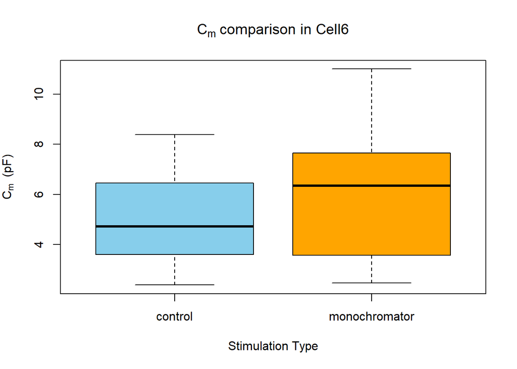

```r
test <- t.test(Cm~Stimulation_Type, data = cell6results_60)
pvalue <- test[3]
if(pvalue < 0.05){
  pvalueis <- "significant"
  decision <- "we reject the null. This means that there is a significant"
  sign <- "<"
  color <-c("skyblue","orange")
} else {
  pvalueis <- "not significant"
  decision <- "we fail to reject the null. This means that there is no significant"
  sign <- ">"
  color <- c("gray58","gray82")
}


boxplot(Cm~Stimulation_Type, data = cell6results_60,outline=FALSE, col=color, main = c(expression(C[m]~"comparison in Cell6")), xlab ="Stimulation Type", ylab=c(expression(C[m]~" (pF)")))
```

```r
cell6results_60 %>%
group_by(Stimulation_Type) %>%
  summarise(min = min(Cm), Q1 = quantile(Cm, 0.25), med = median(Cm), Q3 = quantile(Cm, 0.75), max = max(Cm), mean=mean(Cm), sd =sd(Cm), 'sample size'=n()) %>% pander(caption="Summary Statistics of Cm Cell1", split.table=Inf)
```

Summary Statistics of Cm Cell1

| Stimulation_Type | min | Q1 | med | Q3 | max | mean | sd | sample size |
| --- | --- | --- | --- | --- | --- | --- | --- | --- |
| control | 2.388 | 3.6 | 4.717 | 6.45 | 8.391 | 4.974 | 1.716 | 51 |
| monochromator | 2.463 | 3.593 | 6.353 | 7.607 | 11 | 5.956 | 2.453 | 44 |

Show the diagnostic plots(click to view)

Here are the results of the Independent Samples t Test we get:

```r
pander(t.test(Cm~Stimulation_Type, data = cell6results_60), split.table=Inf)
```

Welch Two Sample t-test: `Cm` by `Stimulation_Type`

| Test statistic | df | P value | Alternative hypothesis | mean in group control | mean in group monochromator |
| --- | --- | --- | --- | --- | --- |
| -2.227 | 75.4 | 0.0289 * | two.sided | 4.974 | 5.956 |

Since, our P-value is significant (0.0289027 < $\alpha$), we reject the null. This means that there is a significant evidence to conclude that when the axons of RVM are stimulated with monochromator membrane capacitance of the cell changes significantly from that when there is no light stimulation.

##### Cell 7

Below is the boxplot comparison of the $C_m$ values of the cell that was not stimulated by light (control) and the values when it was stimulated by light (monochromator):

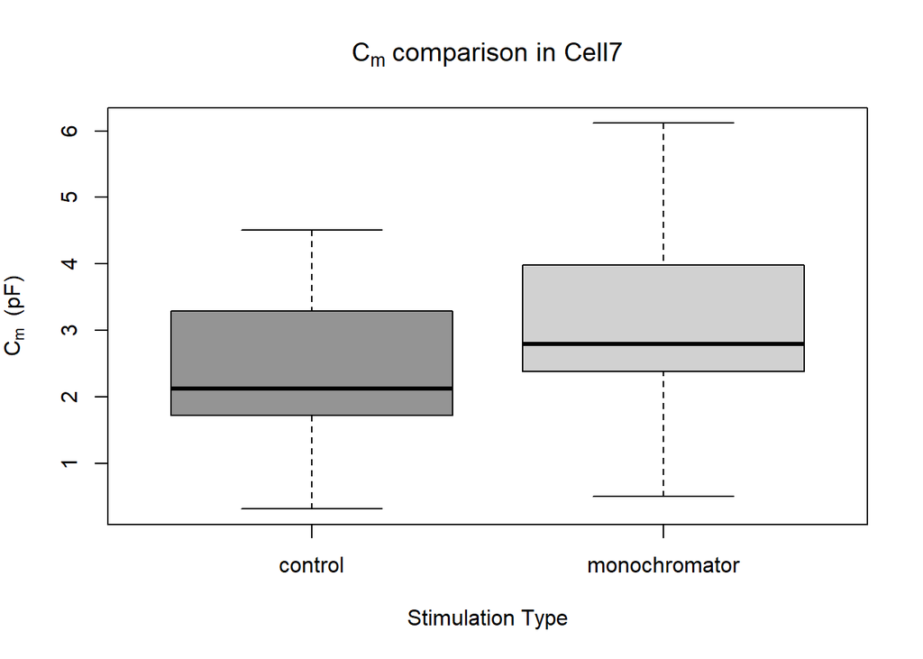

```r
test <- t.test(Cm~Stimulation_Type, data = cell7results)
pvalue <- test[3]
if(pvalue < 0.05){
  pvalueis <- "significant"
  decision <- "we reject the null. This means that there is a significant"
  sign <- "<"
  color <-c("skyblue","orange")
} else {
  pvalueis <- "not significant"
  decision <- "we fail to reject the null. This means that there is no significant"
  sign <- ">"
  color <- c("gray58","gray82")
}


boxplot(Cm~Stimulation_Type, data = cell7results,outline=FALSE, col=color, main = c(expression(C[m]~"comparison in Cell7")), xlab ="Stimulation Type", ylab=c(expression(C[m]~" (pF)")))
```

```r
cell7results %>%
group_by(Stimulation_Type) %>%
  summarise(min = min(Cm), Q1 = quantile(Cm, 0.25), med = median(Cm), Q3 = quantile(Cm, 0.75), max = max(Cm), mean=mean(Cm), sd =sd(Cm), 'sample size'=n()) %>% pander(caption="Summary Statistics of Cm Cell1", split.table=Inf)
```

Summary Statistics of Cm Cell1

| Stimulation_Type | min | Q1 | med | Q3 | max | mean | sd | sample size |
| --- | --- | --- | --- | --- | --- | --- | --- | --- |
| control | 0.3176 | 1.728 | 2.124 | 3.294 | 6.68 | 2.656 | 1.513 | 39 |
| monochromator | 0.5014 | 2.379 | 2.792 | 3.98 | 8.797 | 3.49 | 2.269 | 17 |

Show the diagnostic plots(click to view)

Here are the results of the Independent Samples t Test we get:

```r
pander(t.test(Cm~Stimulation_Type, data = cell7results), split.table=Inf)
```

Welch Two Sample t-test: `Cm` by `Stimulation_Type`

| Test statistic | df | P value | Alternative hypothesis | mean in group control | mean in group monochromator |
| --- | --- | --- | --- | --- | --- |
| -1.388 | 22.45 | 0.1787 | two.sided | 2.656 | 3.49 |

Since, our P-value is not significant (0.1787289 > $\alpha$), we fail to reject the null. This means that there is no significant evidence to conclude that when the axons of RVM are stimulated with monochromator membrane capacitance of the cell changes significantly from that when there is no light stimulation.

##### Cell 8

###### VC = -10

Below is the boxplot comparison of the $C_m$ values of the cell that was not stimulated by light (control) and the values when it was stimulated by light (monochromator):

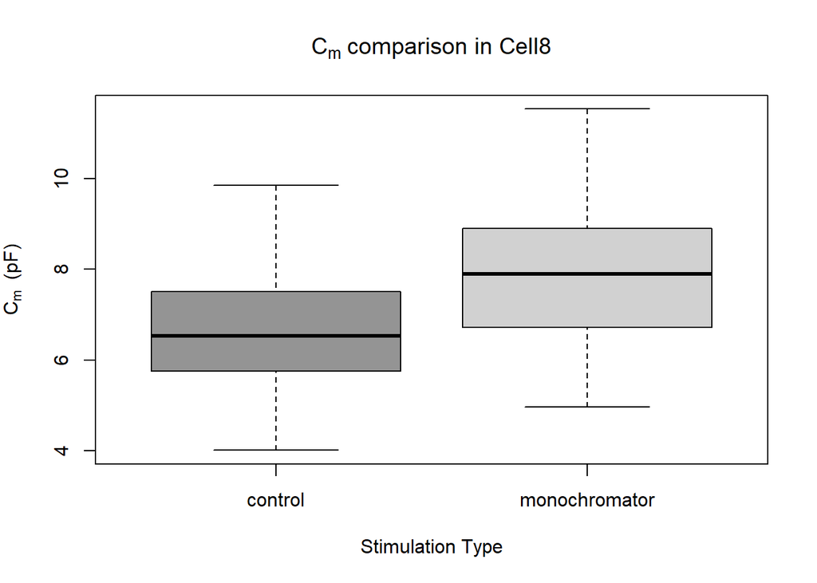

```r
test <- t.test(Cm~Stimulation_Type, data = cell8results_10)
pvalue <- test[3]
if(pvalue < 0.05){
  pvalueis <- "significant"
  decision <- "we reject the null. This means that there is a significant"
  sign <- "<"
  color <-c("skyblue","orange")
} else {
  pvalueis <- "not significant"
  decision <- "we fail to reject the null. This means that there is no significant"
  sign <- ">"
  color <- c("gray58","gray82")
}


boxplot(Cm~Stimulation_Type, data = cell8results_10,outline=FALSE, col=color, main = c(expression(C[m]~"comparison in Cell8")), xlab ="Stimulation Type", ylab=c(expression(C[m]~" (pF)")))
```

```r
cell8results_10 %>%
group_by(Stimulation_Type) %>%
  summarise(min = min(Cm), Q1 = quantile(Cm, 0.25), med = median(Cm), Q3 = quantile(Cm, 0.75), max = max(Cm), mean=mean(Cm), sd =sd(Cm), 'sample size'=n()) %>% pander(caption="Summary Statistics of Cm Cell1", split.table=Inf)
```

Summary Statistics of Cm Cell1

| Stimulation_Type | min | Q1 | med | Q3 | max | mean | sd | sample size |
| --- | --- | --- | --- | --- | --- | --- | --- | --- |
| control | 4.011 | 5.788 | 6.529 | 7.445 | 9.849 | 6.702 | 1.579 | 26 |
| monochromator | 2.799 | 6.727 | 7.901 | 8.791 | 18.07 | 8.323 | 3.298 | 18 |

Show the diagnostic plots(click to view)

Here are the results of the Independent Samples t Test we get:

```r
pander(t.test(Cm~Stimulation_Type, data = cell8results_10), split.table=Inf)
```

Welch Two Sample t-test: `Cm` by `Stimulation_Type`

| Test statistic | df | P value | Alternative hypothesis | mean in group control | mean in group monochromator |
| --- | --- | --- | --- | --- | --- |
| -1.937 | 22.44 | 0.06546 | two.sided | 6.702 | 8.323 |

Since, our P-value is not significant (0.0654597 > $\alpha$), we fail to reject the null. This means that there is no significant evidence to conclude that when the axons of RVM are stimulated with monochromator membrane capacitance of the cell changes significantly from that when there is no light stimulation.

###### VC = -60

Below is the boxplot comparison of the $C_m$ values of the cell that was not stimulated by light (control) and the values when it was stimulated by light (monochromator):

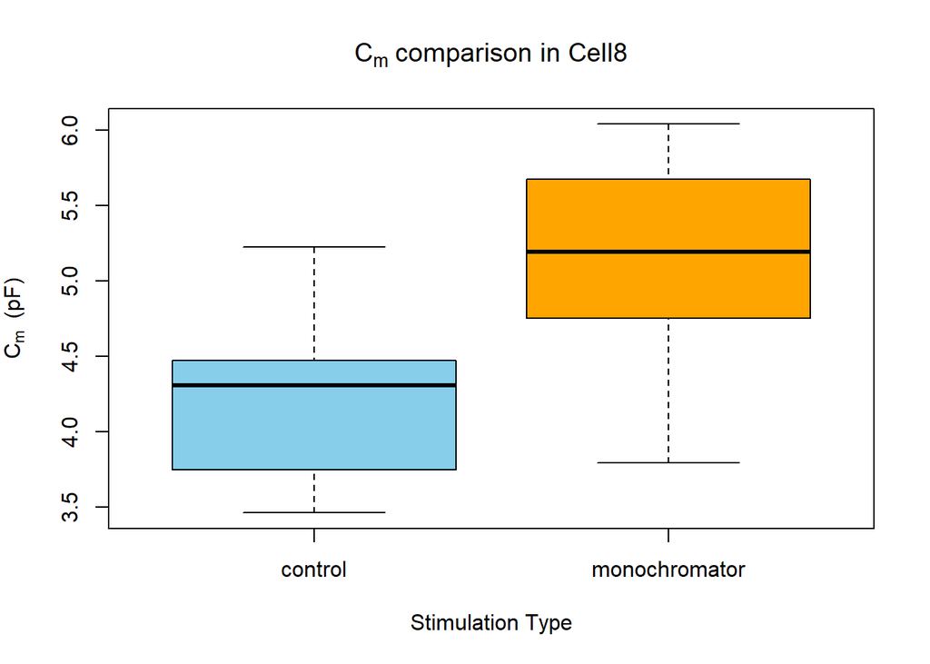

```r
test <- t.test(Cm~Stimulation_Type, data = cell8results_60)
pvalue <- test[3]
if(pvalue < 0.05){
  pvalueis <- "significant"
  decision <- "we reject the null. This means that there is a significant"
  sign <- "<"
  color <-c("skyblue","orange")
} else {
  pvalueis <- "not significant"
  decision <- "we fail to reject the null. This means that there is no significant"
  sign <- ">"
  color <- c("gray58","gray82")
}


boxplot(Cm~Stimulation_Type, data = cell8results_60,outline=FALSE, col=color, main = c(expression(C[m]~"comparison in Cell8")), xlab ="Stimulation Type", ylab=c(expression(C[m]~" (pF)")))
```

```r
cell8results_60 %>%
group_by(Stimulation_Type) %>%
  summarise(min = min(Cm), Q1 = quantile(Cm, 0.25), med = median(Cm), Q3 = quantile(Cm, 0.75), max = max(Cm), mean=mean(Cm), sd =sd(Cm), 'sample size'=n()) %>% pander(caption="Summary Statistics of Cm Cell1", split.table=Inf)
```

Summary Statistics of Cm Cell1

| Stimulation_Type | min | Q1 | med | Q3 | max | mean | sd | sample size |
| --- | --- | --- | --- | --- | --- | --- | --- | --- |
| control | 3.462 | 3.745 | 4.306 | 4.473 | 5.223 | 4.238 | 0.5476 | 13 |
| monochromator | 3.795 | 4.794 | 5.194 | 5.639 | 6.04 | 5.163 | 0.6444 | 18 |

Show the diagnostic plots(click to view)

Here are the results of the Independent Samples t Test we get:

```r
pander(t.test(Cm~Stimulation_Type, data = cell8results_60), split.table=Inf)
```

Welch Two Sample t-test: `Cm` by `Stimulation_Type`

| Test statistic | df | P value | Alternative hypothesis | mean in group control | mean in group monochromator |
| --- | --- | --- | --- | --- | --- |
| -4.306 | 28.14 | 0.0001823 * * * | two.sided | 4.238 | 5.163 |

Since, our P-value is significant (1.8229896^{-4} < $\alpha$), we reject the null. This means that there is a significant evidence to conclude that when the axons of RVM are stimulated with monochromator membrane capacitance of the cell changes significantly from that when there is no light stimulation.

## Normalized Data Analysis

### Hide Data

```r
norm_results <-read_csv("Normalization_result.csv")
norm_results$X1 <- NULL
```

#### $R_m$

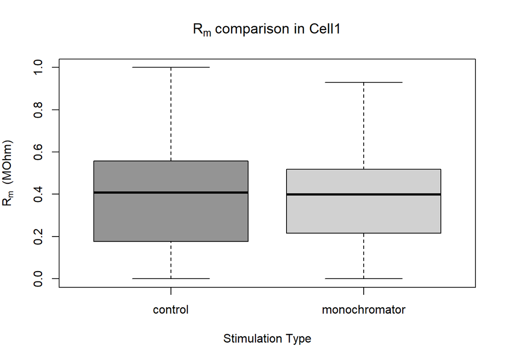

```r
test <- t.test(Rm_scaled~Stimulation_Type, data = norm_results)
pvalue <- test[3]
if(pvalue < 0.05){
  pvalueis <- "significant"
  decision <- "we reject the null. This means that there is a significant"
  sign <- "<"
  color <-c("skyblue","orange")
} else {
  pvalueis <- "not significant"
  decision <- "we fail to reject the null. This means that there is no significant"
  sign <- ">"
  color <- c("gray58","gray82")
}


boxplot(Rm_scaled~Stimulation_Type, data = norm_results,outline=FALSE, col=color, main = c(expression(R[m]~"comparison in Cell1")), xlab ="Stimulation Type", ylab=c(expression(R[m]~" (MOhm)")))
```

```r
norm_results %>%
group_by(Stimulation_Type) %>%
  summarise(min = min(Rm_scaled), Q1 = quantile(Rm_scaled, 0.25), med = median(Rm_scaled), Q3 = quantile(Rm_scaled, 0.75), max = max(Rm_scaled), mean=mean(Rm_scaled), sd =sd(Rm_scaled), 'sample size'=n()) %>% pander(caption="Summary Statistics of Rm_scaled Cell1", split.table=Inf)
```

Summary Statistics of Rm_scaled Cell1

| Stimulation_Type | min | Q1 | med | Q3 | max | mean | sd | sample size |
| --- | --- | --- | --- | --- | --- | --- | --- | --- |
| control | 0 | 0.1769 | 0.4079 | 0.5574 | 1 | 0.3854 | 0.2297 | 410 |
| monochromator | 0 | 0.2168 | 0.3994 | 0.519 | 1 | 0.3869 | 0.2192 | 230 |

Show the diagnostic plots(click to view)

Here are the results we get:

```r
pander(t.test(Rm_scaled~Stimulation_Type, data = norm_results), split.table=Inf)
```

Welch Two Sample t-test: `Rm_scaled` by `Stimulation_Type`

| Test statistic | df | P value | Alternative hypothesis | mean in group control | mean in group monochromator |
| --- | --- | --- | --- | --- | --- |
| -0.07779 | 493.3 | 0.938 | two.sided | 0.3854 | 0.3869 |

Since, our P-value is not significant (0.9380258 > $\alpha$), we fail to reject the null. This means that there is no significant evidence to conclude that when the axons of RVM are stimulated with monochromator membrane resistance of the cell changes significantly from that when there is no light stimulation.

#### $C_m$

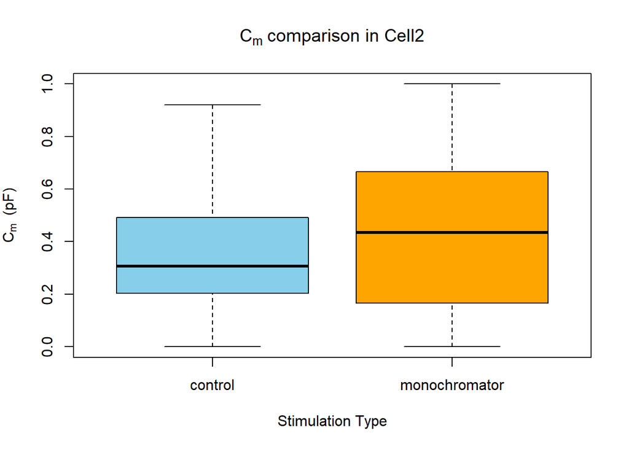

```r
test <- t.test(Cm_scaled~Stimulation_Type, data = norm_results)
pvalue <- test[3]
if(pvalue < 0.05){
  pvalueis <- "significant"
  decision <- "we reject the null. This means that there is a significant"
  sign <- "<"
  color <-c("skyblue","orange")
} else {
  pvalueis <- "not significant"
  decision <- "we fail to reject the null. This means that there is no significant"
  sign <- ">"
  color <- c("gray58","gray82")
}


boxplot(Cm_scaled~Stimulation_Type, data = norm_results,outline=FALSE, col=color, main = c(expression(C[m]~"comparison in Cell2")), xlab ="Stimulation Type", ylab=c(expression(C[m]~" (pF)")))
```

```r
norm_results %>%
group_by(Stimulation_Type) %>%
  summarise(min = min(Cm_scaled), Q1 = quantile(Cm_scaled, 0.25), med = median(Cm_scaled), Q3 = quantile(Cm_scaled, 0.75), max = max(Cm_scaled), mean=mean(Cm_scaled), sd =sd(Cm_scaled), 'sample size'=n()) %>% pander(caption="Summary Statistics of Cm_scaled Cell1", split.table=Inf)
```

Summary Statistics of Cm_scaled Cell1

| Stimulation_Type | min | Q1 | med | Q3 | max | mean | sd | sample size |
| --- | --- | --- | --- | --- | --- | --- | --- | --- |
| control | 0 | 0.2027 | 0.3058 | 0.4919 | 1 | 0.3801 | 0.2554 | 410 |
| monochromator | 0 | 0.168 | 0.4351 | 0.6655 | 1 | 0.436 | 0.2977 | 230 |

Show the diagnostic plots(click to view)

Here are the results of the Independent Samples t Test we get:

```r
pander(t.test(Cm_scaled~Stimulation_Type, data = norm_results), split.table=Inf)
```

Welch Two Sample t-test: `Cm_scaled` by `Stimulation_Type`

| Test statistic | df | P value | Alternative hypothesis | mean in group control | mean in group monochromator |
| --- | --- | --- | --- | --- | --- |
| -2.396 | 417.4 | 0.017 * | two.sided | 0.3801 | 0.436 |

Since, our P-value is significant (0.0169986 < $\alpha$), we reject the null. This means that there is a significant evidence to conclude that when the axons of RVM are stimulated with monochromator membrane capacitance of the cell changes significantly from that when there is no light stimulation.

### Show Data

Here is the link to the google colab where the data was normalized using MinMaxScaler() from sklearn.preprocessing to obtain columns ‘Rm_scaled’ and ‘Cm_scaled’:

https://colab.research.google.com/gist/stassy8/ecbdab4168879c5f1177e650481df3af/min_max_datanormalization.ipynb

```r
datatable(norm_results)
```

|  | file | peak | plato | Ra | Rm+Ra | Rm | tau | Cm | Ih | Cell | Stimulation_Type | VC | Rm_scaled | Cm_scaled |
| --- | --- | --- | --- | --- | --- | --- | --- | --- | --- | --- | --- | --- | --- | --- |
| 1 | 2020_02_13_0000 | -337.6319275 | -42.69101334 | 29.61805204 | 234.241336 | 204.623284 | 0.308941841 | 1.509807853 | 150.2105408 | 1 | control | -10 | 0.144549417653404 | 0.508159216099857 |
| 2 | 2020_02_13_0000 | -337.9321594 | -37.43323135 | 29.59173823 | 267.1423128 | 237.5505746 | 0.337508887 | 1.4207875 | 121.2714691 | 1 | control | -10 | 0.268198350096561 | 0.434359682882956 |
| 3 | 2020_02_13_0000 | -334.2667542 | -40.65335083 | 29.91622671 | 245.9821834 | 216.0659567 | 0.365314752 | 1.690755719 | 106.8414459 | 1 | control | -10 | 0.187519071028148 | 0.658168372403635 |
| 4 | 2020_02_13_0000 | -322.5341492 | -33.38394165 | 31.00446891 | 299.5452156 | 268.5407467 | 0.317153513 | 1.181025663 | 100.4554443 | 1 | control | -10 | 0.384572993335344 | 0.23559264750817 |
| 5 | 2020_02_13_0000 | -325.8511658 | -29.47973251 | 30.68885752 | 339.2161037 | 308.5272461 | 0.322646081 | 1.045762037 | 99.50927734 | 1 | control | -10 | 0.534730746155401 | 0.123456578355247 |
| 6 | 2020_02_13_0000 | -320.9894714 | -30.11119652 | 31.15366979 | 332.1023791 | 300.9487093 | 0.332927316 | 1.106259327 | 90.50647736 | 1 | control | -10 | 0.506271739424942 | 0.173609960277779 |
| 7 | 2020_02_13_0000 | -326.1824036 | -30.26491737 | 30.65769303 | 330.4155725 | 299.7578794 | 0.343033224 | 1.144367664 | 87.8026886 | 1 | control | -10 | 0.501799921574966 | 0.20520248252123 |
| 8 | 2020_02_13_0000 | -309.3432922 | -21.51678658 | 32.32654546 | 464.7534131 | 432.4268676 | 0.387819052 | 0.896843098 | 78.87238312 | 1 | control | -10 | 1 | 0 |
| 9 | 2020_02_13_0000 | -317.0970764 | -36.25908661 | 31.53608388 | 275.7929373 | 244.2568534 | 0.350610852 | 1.435418689 | 67.83554077 | 1 | control | -10 | 0.293381843763246 | 0.446489211493208 |
| 10 | 2020_02_13_0000 | -311.3063354 | -36.82743454 | 32.12269993 | 271.5366988 | 239.4139989 | 0.343214959 | 1.433562618 | 71.40598297 | 1 | control | -10 | 0.275195902011253 | 0.44495049401118 |

[output cut: 630 more lines]

## Standardized Data Analysis

### Hide Data

```r
standard_results <-read_csv("Standardization_result.csv")
standard_results$X1 <- NULL
```

#### $R_m$

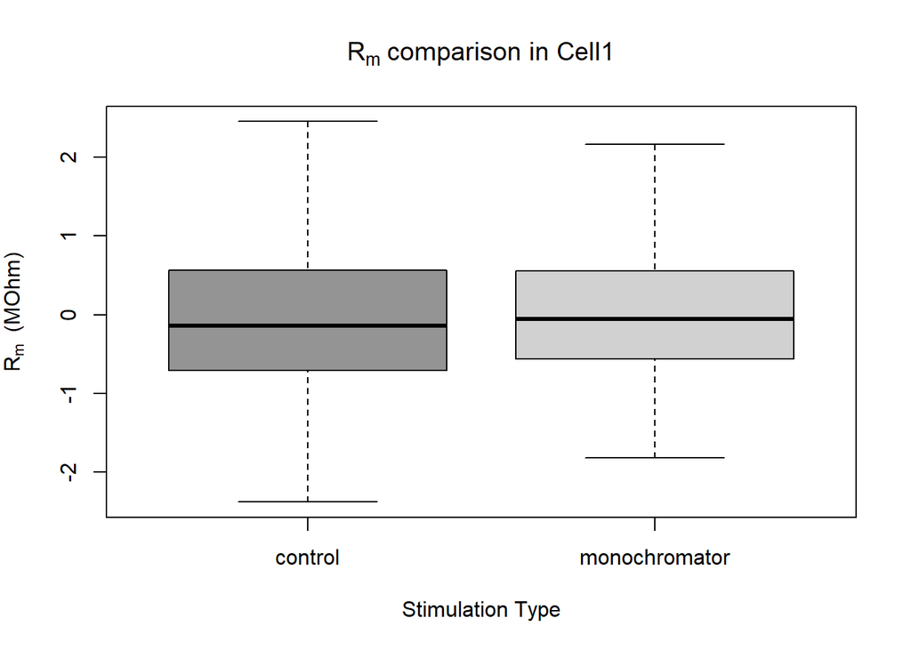

```r
test <- t.test(Rm_scaled~Stimulation_Type, data = standard_results)
pvalue <- test[3]
if(pvalue < 0.05){
  pvalueis <- "significant"
  decision <- "we reject the null. This means that there is a significant"
  sign <- "<"
  color <-c("skyblue","orange")
} else {
  pvalueis <- "not significant"
  decision <- "we fail to reject the null. This means that there is no significant"
  sign <- ">"
  color <- c("gray58","gray82")
}


boxplot(Rm_scaled~Stimulation_Type, data = standard_results,outline=FALSE, col=color, main = c(expression(R[m]~"comparison in Cell1")), xlab ="Stimulation Type", ylab=c(expression(R[m]~" (MOhm)")))
```

```r
standard_results %>%
group_by(Stimulation_Type) %>%
  summarise(min = min(Rm_scaled), Q1 = quantile(Rm_scaled, 0.25), med = median(Rm_scaled), Q3 = quantile(Rm_scaled, 0.75), max = max(Rm_scaled), mean=mean(Rm_scaled), sd =sd(Rm_scaled), 'sample size'=n()) %>% pander(caption="Summary Statistics of Rm_scaled Cell1", split.table=Inf)
```

Summary Statistics of Rm_scaled Cell1

| Stimulation_Type | min | Q1 | med | Q3 | max | mean | sd | sample size |
| --- | --- | --- | --- | --- | --- | --- | --- | --- |
| control | -4.293 | -0.7052 | -0.1357 | 0.5652 | 5.96 | -0.0276 | 1.027 | 410 |
| monochromator | -2.699 | -0.5537 | -0.05612 | 0.5529 | 3.574 | 0.0492 | 0.9525 | 230 |

Show the diagnostic plots(click to view)

Here are the results we get:

```r
pander(t.test(Rm_scaled~Stimulation_Type, data = standard_results), split.table=Inf)
```

Welch Two Sample t-test: `Rm_scaled` by `Stimulation_Type`

| Test statistic | df | P value | Alternative hypothesis | mean in group control | mean in group monochromator |
| --- | --- | --- | --- | --- | --- |
| -0.9514 | 504.8 | 0.3419 | two.sided | -0.0276 | 0.0492 |

Since, our P-value is not significant (0.341876 > $\alpha$), we fail to reject the null. This means that there is no significant evidence to conclude that when the axons of RVM are stimulated with monochromator membrane resistance of the cell changes significantly from that when there is no light stimulation.

#### $C_m$

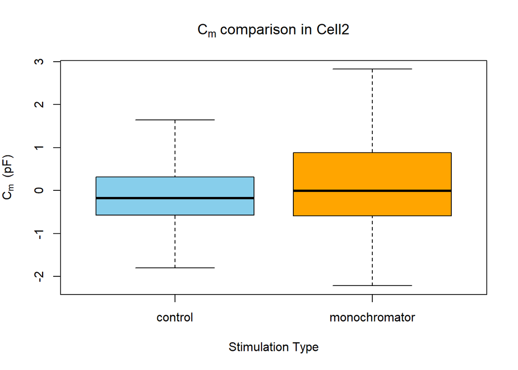

```r
test <- t.test(Cm_scaled~Stimulation_Type, data = standard_results)
pvalue <- test[3]
if(pvalue < 0.05){
  pvalueis <- "significant"
  decision <- "we reject the null. This means that there is a significant"
  sign <- "<"
  color <-c("skyblue","orange")
} else {
  pvalueis <- "not significant"
  decision <- "we fail to reject the null. This means that there is no significant"
  sign <- ">"
  color <- c("gray58","gray82")
}


boxplot(Cm_scaled~Stimulation_Type, data = standard_results,outline=FALSE, col=color, main = c(expression(C[m]~"comparison in Cell2")), xlab ="Stimulation Type", ylab=c(expression(C[m]~" (pF)")))
```

```r
standard_results %>%
group_by(Stimulation_Type) %>%
  summarise(min = min(Cm_scaled), Q1 = quantile(Cm_scaled, 0.25), med = median(Cm_scaled), Q3 = quantile(Cm_scaled, 0.75), max = max(Cm_scaled), mean=mean(Cm_scaled), sd =sd(Cm_scaled), 'sample size'=n()) %>% pander(caption="Summary Statistics of Cm_scaled Cell1", split.table=Inf)
```

Summary Statistics of Cm_scaled Cell1

| Stimulation_Type | min | Q1 | med | Q3 | max | mean | sd | sample size |
| --- | --- | --- | --- | --- | --- | --- | --- | --- |
| control | -2.52 | -0.576 | -0.1763 | 0.3139 | 3.869 | -0.1061 | 0.8099 | 410 |
| monochromator | -8.6 | -0.5839 | -0.00626 | 0.8794 | 5.011 | 0.1892 | 1.252 | 230 |

Show the diagnostic plots(click to view)

Here are the results of the Independent Samples t Test we get:

```r
pander(t.test(Cm_scaled~Stimulation_Type, data = standard_results), split.table=Inf)
```

Welch Two Sample t-test: `Cm_scaled` by `Stimulation_Type`

| Test statistic | df | P value | Alternative hypothesis | mean in group control | mean in group monochromator |
| --- | --- | --- | --- | --- | --- |
| -3.219 | 338.7 | 0.00141 * * | two.sided | -0.1061 | 0.1892 |

Since, our P-value is significant (0.0014101 < $\alpha$), we reject the null. This means that there is a significant evidence to conclude that when the axons of RVM are stimulated with monochromator membrane capacitance of the cell changes significantly from that when there is no light stimulation.

### Show Data

Here is the link to the google colab where the data was standardized using StandardScaler() from sklearn.preprocessing to obtain columns ‘Rm_scaled’ and ‘Cm_scaled’:

https://colab.research.google.com/gist/stassy8/6059156381326be744cb015e467d4bae/standard_scalar_datastandardization.ipynb

```r
datatable(standard_results)
```

|  | file | peak | plato | Ra | Rm+Ra | Rm | tau | Cm | Ih | Cell | Stimulation_Type | VC | Rm_scaled | Cm_scaled |
| --- | --- | --- | --- | --- | --- | --- | --- | --- | --- | --- | --- | --- | --- | --- |
| 1 | 2020_02_13_0000 | -337.6319275 | -42.69101334 | 29.61805204 | 234.241336 | 204.623284 | 0.308941841 | 1.509807853 | 150.2105408 | 1 | control | -10 | -0.689899675593697 | -0.0877136582350762 |
| 2 | 2020_02_13_0000 | -337.9321594 | -37.43323135 | 29.59173823 | 267.1423128 | 237.5505746 | 0.337508887 | 1.4207875 | 121.2714691 | 1 | control | -10 | 0.0566791444269068 | -0.440961786843423 |
| 3 | 2020_02_13_0000 | -334.2667542 | -40.65335083 | 29.91622671 | 245.9821834 | 216.0659567 | 0.365314752 | 1.690755719 | 106.8414459 | 1 | control | -10 | -0.430453577035926 | 0.630318711735125 |
| 4 | 2020_02_13_0000 | -322.5341492 | -33.38394165 | 31.00446891 | 299.5452156 | 268.5407467 | 0.317153513 | 1.181025663 | 100.4554443 | 1 | control | -10 | 0.75933659656035 | -1.39237814700939 |
| 5 | 2020_02_13_0000 | -325.8511658 | -29.47973251 | 30.68885752 | 339.2161037 | 308.5272461 | 0.322646081 | 1.045762037 | 99.50927734 | 1 | control | -10 | 1.66597279391594 | -1.92912756602461 |
| 6 | 2020_02_13_0000 | -320.9894714 | -30.11119652 | 31.15366979 | 332.1023791 | 300.9487093 | 0.332927316 | 1.106259327 | 90.50647736 | 1 | control | -10 | 1.49414040325983 | -1.68906387543942 |
| 7 | 2020_02_13_0000 | -326.1824036 | -30.26491737 | 30.65769303 | 330.4155725 | 299.7578794 | 0.343033224 | 1.144367664 | 87.8026886 | 1 | control | -10 | 1.46714005293075 | -1.53784341544387 |
| 8 | 2020_02_13_0000 | -309.3432922 | -21.51678658 | 32.32654546 | 464.7534131 | 432.4268676 | 0.387819052 | 0.896843098 | 78.87238312 | 1 | control | -10 | 4.47521799857513 | -2.52006362438972 |
| 9 | 2020_02_13_0000 | -317.0970764 | -36.25908661 | 31.53608388 | 275.7929373 | 244.2568534 | 0.350610852 | 1.435418689 | 67.83554077 | 1 | control | -10 | 0.208734343078241 | -0.382902703056539 |
| 10 | 2020_02_13_0000 | -311.3063354 | -36.82743454 | 32.12269993 | 271.5366988 | 239.4139989 | 0.343214959 | 1.433562618 | 71.40598297 | 1 | control | -10 | 0.0989296026256064 | -0.390267913204765 |

[output cut: 630 more lines]

## Normalized Data Light-Control and Control-Light Analysis

### Light-Control

#### Hide Data

```r
LC_results <-read_csv("Normalization_result_LC.csv")
```

##### $R_m$

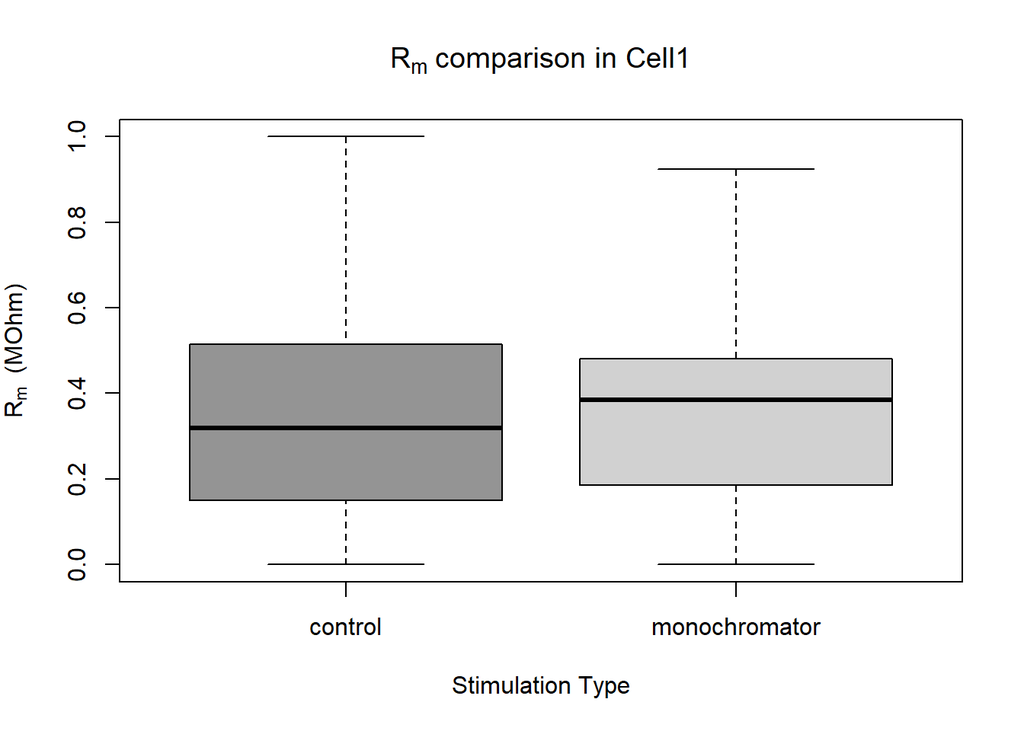

```r
test <- t.test(Rm_scaled~Stimulation_Type, data = LC_results)
pvalue <- test[3]
if(pvalue < 0.05){
  pvalueis <- "significant"
  decision <- "we reject the null. This means that there is a significant"
  sign <- "<"
  color <-c("skyblue","orange")
} else {
  pvalueis <- "not significant"
  decision <- "we fail to reject the null. This means that there is no significant"
  sign <- ">"
  color <- c("gray58","gray82")
}


boxplot(Rm_scaled~Stimulation_Type, data = LC_results,outline=FALSE, col=color, main = c(expression(R[m]~"comparison in Cell1")), xlab ="Stimulation Type", ylab=c(expression(R[m]~" (MOhm)")))
```

```r
LC_results %>%
group_by(Stimulation_Type) %>%
  summarise(min = min(Rm_scaled), Q1 = quantile(Rm_scaled, 0.25), med = median(Rm_scaled), Q3 = quantile(Rm_scaled, 0.75), max = max(Rm_scaled), mean=mean(Rm_scaled), sd =sd(Rm_scaled), 'sample size'=n()) %>% pander(caption="Summary Statistics of Rm_scaled Cell1", split.table=Inf)
```

Summary Statistics of Rm_scaled Cell1

| Stimulation_Type | min | Q1 | med | Q3 | max | mean | sd | sample size |
| --- | --- | --- | --- | --- | --- | --- | --- | --- |
| control | 0 | 0.1496 | 0.3197 | 0.5143 | 1 | 0.3383 | 0.2143 | 265 |
| monochromator | 0 | 0.185 | 0.3846 | 0.4817 | 1 | 0.3583 | 0.2088 | 183 |

Show the diagnostic plots(click to view)

Here are the results we get:

```r
pander(t.test(Rm_scaled~Stimulation_Type, data = LC_results), split.table=Inf)
```

Welch Two Sample t-test: `Rm_scaled` by `Stimulation_Type`

| Test statistic | df | P value | Alternative hypothesis | mean in group control | mean in group monochromator |
| --- | --- | --- | --- | --- | --- |
| -0.9875 | 397.9 | 0.324 | two.sided | 0.3383 | 0.3583 |

Since, our P-value is not significant (0.323984 > $\alpha$), we fail to reject the null. This means that there is no significant evidence to conclude that when the axons of RVM are stimulated with monochromator membrane resistance of the cell changes significantly from that when there is no light stimulation.

##### $C_m$

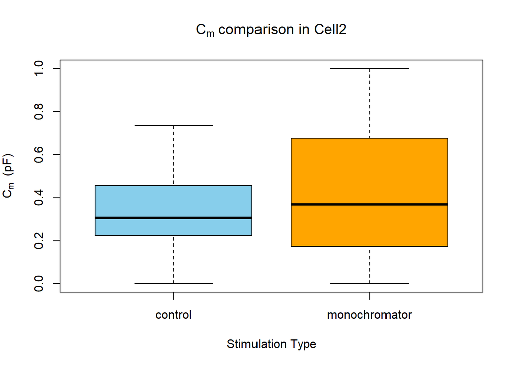

```r
test <- t.test(Cm_scaled~Stimulation_Type, data = LC_results)
pvalue <- test[3]
if(pvalue < 0.05){
  pvalueis <- "significant"
  decision <- "we reject the null. This means that there is a significant"
  sign <- "<"
  color <-c("skyblue","orange")
} else {
  pvalueis <- "not significant"
  decision <- "we fail to reject the null. This means that there is no significant"
  sign <- ">"
  color <- c("gray58","gray82")
}


boxplot(Cm_scaled~Stimulation_Type, data = LC_results,outline=FALSE, col=color, main = c(expression(C[m]~"comparison in Cell2")), xlab ="Stimulation Type", ylab=c(expression(C[m]~" (pF)")))
```

```r
LC_results %>%
group_by(Stimulation_Type) %>%
  summarise(min = min(Cm_scaled), Q1 = quantile(Cm_scaled, 0.25), med = median(Cm_scaled), Q3 = quantile(Cm_scaled, 0.75), max = max(Cm_scaled), mean=mean(Cm_scaled), sd =sd(Cm_scaled), 'sample size'=n()) %>% pander(caption="Summary Statistics of Cm_scaled Cell1", split.table=Inf)
```

Summary Statistics of Cm_scaled Cell1

| Stimulation_Type | min | Q1 | med | Q3 | max | mean | sd | sample size |
| --- | --- | --- | --- | --- | --- | --- | --- | --- |
| control | 0 | 0.2207 | 0.3053 | 0.4559 | 1 | 0.375 | 0.2351 | 265 |
| monochromator | 0 | 0.1735 | 0.3667 | 0.677 | 1 | 0.4347 | 0.3025 | 183 |

Show the diagnostic plots(click to view)

Here are the results of the Independent Samples t Test we get:

```r
pander(t.test(Cm_scaled~Stimulation_Type, data = LC_results), split.table=Inf)
```

Welch Two Sample t-test: `Cm_scaled` by `Stimulation_Type`

| Test statistic | df | P value | Alternative hypothesis | mean in group control | mean in group monochromator |
| --- | --- | --- | --- | --- | --- |
| -2.245 | 326.3 | 0.02542 * | two.sided | 0.375 | 0.4347 |

Since, our P-value is significant (0.0254174 < $\alpha$), we reject the null. This means that there is a significant evidence to conclude that when the axons of RVM are stimulated with monochromator membrane capacitance of the cell changes significantly from that when there is no light stimulation.

#### Show Data

The data was filtered to only contain the sets that had first light recorded and then control.

```r
datatable(LC_results)
```

|  | file | peak | plato | Ra | Rm+Ra | Rm | tau | Cm | Ih | Cell | Stimulation_Type | VC | Rm_scaled | Cm_scaled |
| --- | --- | --- | --- | --- | --- | --- | --- | --- | --- | --- | --- | --- | --- | --- |
| 1 | 2020_02_13_0001 | -305.400116 | -42.19713974 | 32.74392994 | 236.982887 | 204.2389571 | 0.345232457 | 1.690335976 | 67.20227814 | 1 | monochromator | -10 | 0.143106189 | 0.657820398 |
| 2 | 2020_02_13_0001 | -311.1176147 | -47.49095917 | 32.14218523 | 210.5663936 | 178.4242084 | 0.327215433 | 1.833918369 | 60.80304718 | 1 | monochromator | -10 | 0.046166354 | 0.77685288 |
| 3 | 2020_02_13_0001 | -311.9952087 | -38.07676697 | 32.05177426 | 262.6273394 | 230.5755651 | 0.371931851 | 1.613058395 | 58.05560684 | 1 | monochromator | -10 | 0.242005716 | 0.593755841 |
| 4 | 2020_02_13_0001 | -317.9436646 | -45.21635437 | 31.4521128 | 221.1589178 | 189.706805 | 0.364700109 | 1.922440836 | 63.6639595 | 1 | monochromator | -10 | 0.088534888 | 0.850239656 |
| 5 | 2020_02_13_0001 | -317.0693665 | -38.78451157 | 31.53883994 | 257.834883 | 226.296043 | 0.353331655 | 1.561369128 | 66.03831482 | 1 | monochromator | -10 | 0.225935206 | 0.550904475 |
| 6 | 2020_02_13_0001 | -311.4673157 | -27.56777 | 32.10609748 | 362.7424343 | 330.6363368 | 0.32184875 | 0.973422199 | 60.67237854 | 1 | monochromator | -10 | 0.617755053 | 0.063485503 |
| 7 | 2020_02_13_0001 | -312.6649475 | -38.2364769 | 31.98311829 | 261.5303713 | 229.547253 | 0.306379795 | 1.334713402 | 67.92954254 | 1 | monochromator | -10 | 0.238144187 | 0.36300265 |
| 8 | 2020_02_13_0001 | -316.3798218 | -38.34563828 | 31.60757833 | 260.7858534 | 229.178275 | 0.326706648 | 1.425556798 | 68.88890839 | 1 | monochromator | -10 | 0.236758596 | 0.43831352 |
| 9 | 2020_02_13_0001 | -311.539917 | -39.39121246 | 32.09861547 | 253.8637268 | 221.7651113 | 0.330247253 | 1.489175872 | 69.75888062 | 1 | monochromator | -10 | 0.208920601 | 0.491054919 |
| 10 | 2020_02_13_0001 | -309.1216125 | -37.98895645 | 32.34972773 | 263.2343958 | 230.8846681 | 0.352989942 | 1.528858303 | 67.82122803 | 1 | monochromator | -10 | 0.243166463 | 0.523952395 |

[output cut: 438 more lines]

### Control-Light

#### Hide Data

```r
CL_results <-read_csv("Normalization_result_CL.csv")
```

##### $R_m$

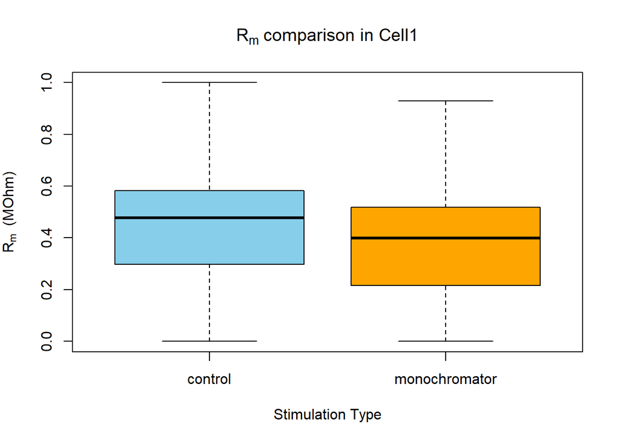

```r
test <- t.test(Rm_scaled~Stimulation_Type, data = CL_results)
pvalue <- test[3]
if(pvalue < 0.05){
  pvalueis <- "significant"
  decision <- "we reject the null. This means that there is a significant"
  sign <- "<"
  color <-c("skyblue","orange")
} else {
  pvalueis <- "not significant"
  decision <- "we fail to reject the null. This means that there is no significant"
  sign <- ">"
  color <- c("gray58","gray82")
}


boxplot(Rm_scaled~Stimulation_Type, data = CL_results,outline=FALSE, col=color, main = c(expression(R[m]~"comparison in Cell1")), xlab ="Stimulation Type", ylab=c(expression(R[m]~" (MOhm)")))
```

```r
CL_results %>%
group_by(Stimulation_Type) %>%
  summarise(min = min(Rm_scaled), Q1 = quantile(Rm_scaled, 0.25), med = median(Rm_scaled), Q3 = quantile(Rm_scaled, 0.75), max = max(Rm_scaled), mean=mean(Rm_scaled), sd =sd(Rm_scaled), 'sample size'=n()) %>% pander(caption="Summary Statistics of Rm_scaled Cell1", split.table=Inf)
```

Summary Statistics of Rm_scaled Cell1

| Stimulation_Type | min | Q1 | med | Q3 | max | mean | sd | sample size |
| --- | --- | --- | --- | --- | --- | --- | --- | --- |
| control | 0 | 0.2977 | 0.4772 | 0.5832 | 1 | 0.443 | 0.2145 | 333 |
| monochromator | 0 | 0.2168 | 0.3994 | 0.519 | 1 | 0.3869 | 0.2192 | 230 |

Show the diagnostic plots(click to view)

Here are the results we get:

```r
pander(t.test(Rm_scaled~Stimulation_Type, data = CL_results), split.table=Inf)
```

Welch Two Sample t-test: `Rm_scaled` by `Stimulation_Type`

| Test statistic | df | P value | Alternative hypothesis | mean in group control | mean in group monochromator |
| --- | --- | --- | --- | --- | --- |
| 3.016 | 485.7 | 0.002694 * * | two.sided | 0.443 | 0.3869 |

Since, our P-value is significant (0.0026936 < $\alpha$), we reject the null. This means that there is a significant evidence to conclude that when the axons of RVM are stimulated with monochromator membrane resistance of the cell changes significantly from that when there is no light stimulation.

##### $C_m$

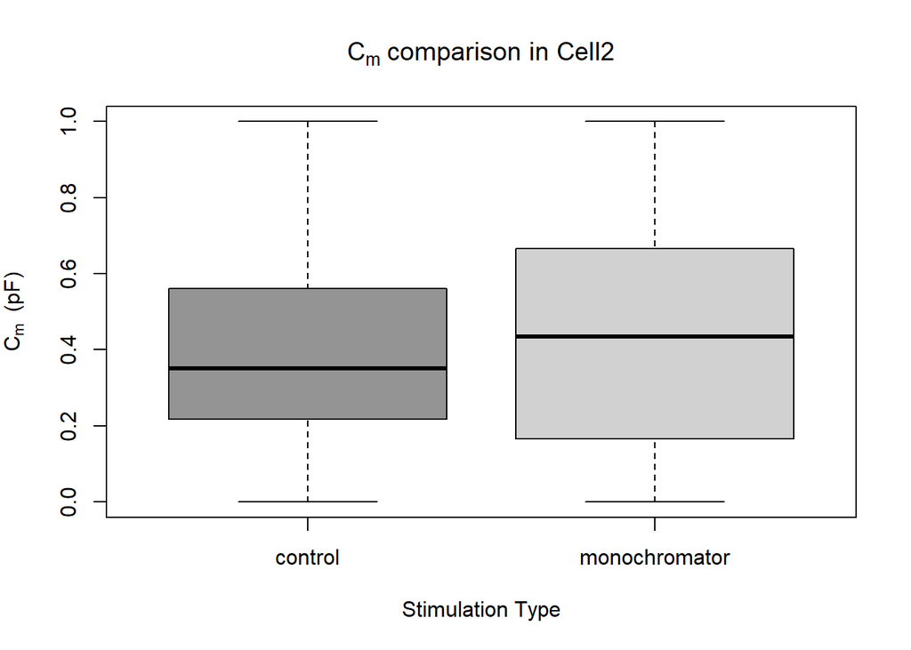

```r
test <- t.test(Cm_scaled~Stimulation_Type, data = CL_results)
pvalue <- test[3]
if(pvalue < 0.05){
  pvalueis <- "significant"
  decision <- "we reject the null. This means that there is a significant"
  sign <- "<"
  color <-c("skyblue","orange")
} else {
  pvalueis <- "not significant"
  decision <- "we fail to reject the null. This means that there is no significant"
  sign <- ">"
  color <- c("gray58","gray82")
}


boxplot(Cm_scaled~Stimulation_Type, data = CL_results,outline=FALSE, col=color, main = c(expression(C[m]~"comparison in Cell2")), xlab ="Stimulation Type", ylab=c(expression(C[m]~" (pF)")))
```

```r
CL_results %>%
group_by(Stimulation_Type) %>%
  summarise(min = min(Cm_scaled), Q1 = quantile(Cm_scaled, 0.25), med = median(Cm_scaled), Q3 = quantile(Cm_scaled, 0.75), max = max(Cm_scaled), mean=mean(Cm_scaled), sd =sd(Cm_scaled), 'sample size'=n()) %>% pander(caption="Summary Statistics of Cm_scaled Cell1", split.table=Inf)
```

Summary Statistics of Cm_scaled Cell1

| Stimulation_Type | min | Q1 | med | Q3 | max | mean | sd | sample size |
| --- | --- | --- | --- | --- | --- | --- | --- | --- |
| control | 0 | 0.2176 | 0.351 | 0.5604 | 1 | 0.4117 | 0.2701 | 333 |
| monochromator | 0 | 0.168 | 0.4351 | 0.6655 | 1 | 0.436 | 0.2977 | 230 |

Show the diagnostic plots(click to view)

Here are the results of the Independent Samples t Test we get:

```r
pander(t.test(Cm_scaled~Stimulation_Type, data = CL_results), split.table=Inf)
```

Welch Two Sample t-test: `Cm_scaled` by `Stimulation_Type`

| Test statistic | df | P value | Alternative hypothesis | mean in group control | mean in group monochromator |
| --- | --- | --- | --- | --- | --- |
| -0.9912 | 460.7 | 0.3221 | two.sided | 0.4117 | 0.436 |

Since, our P-value is not significant (0.3221177 > $\alpha$), we fail to reject the null. This means that there is no significant evidence to conclude that when the axons of RVM are stimulated with monochromator membrane capacitance of the cell changes significantly from that when there is no light stimulation.

#### Show Data

The data was filtered to only contain the sets that had first control recorded and then light.

```r
datatable(CL_results)
```

|  | file | peak | plato | Ra | Rm+Ra | Rm | tau | Cm | Ih | Cell | Stimulation_Type | VC | Rm_scaled | Cm_scaled |
| --- | --- | --- | --- | --- | --- | --- | --- | --- | --- | --- | --- | --- | --- | --- |
| 1 | 2020_02_13_0000 | -337.6319275 | -42.69101334 | 29.61805204 | 234.241336 | 204.623284 | 0.308941841 | 1.509807853 | 150.2105408 | 1 | control | -10 | 0.144549418 | 0.508159216 |
| 2 | 2020_02_13_0000 | -337.9321594 | -37.43323135 | 29.59173823 | 267.1423128 | 237.5505746 | 0.337508887 | 1.4207875 | 121.2714691 | 1 | control | -10 | 0.26819835 | 0.434359683 |
| 3 | 2020_02_13_0000 | -334.2667542 | -40.65335083 | 29.91622671 | 245.9821834 | 216.0659567 | 0.365314752 | 1.690755719 | 106.8414459 | 1 | control | -10 | 0.187519071 | 0.658168372 |
| 4 | 2020_02_13_0000 | -322.5341492 | -33.38394165 | 31.00446891 | 299.5452156 | 268.5407467 | 0.317153513 | 1.181025663 | 100.4554443 | 1 | control | -10 | 0.384572993 | 0.235592648 |
| 5 | 2020_02_13_0000 | -325.8511658 | -29.47973251 | 30.68885752 | 339.2161037 | 308.5272461 | 0.322646081 | 1.045762037 | 99.50927734 | 1 | control | -10 | 0.534730746 | 0.123456578 |
| 6 | 2020_02_13_0000 | -320.9894714 | -30.11119652 | 31.15366979 | 332.1023791 | 300.9487093 | 0.332927316 | 1.106259327 | 90.50647736 | 1 | control | -10 | 0.506271739 | 0.17360996 |
| 7 | 2020_02_13_0000 | -326.1824036 | -30.26491737 | 30.65769303 | 330.4155725 | 299.7578794 | 0.343033224 | 1.144367664 | 87.8026886 | 1 | control | -10 | 0.501799922 | 0.205202483 |
| 8 | 2020_02_13_0000 | -309.3432922 | -21.51678658 | 32.32654546 | 464.7534131 | 432.4268676 | 0.387819052 | 0.896843098 | 78.87238312 | 1 | control | -10 | 1 | 0 |
| 9 | 2020_02_13_0000 | -317.0970764 | -36.25908661 | 31.53608388 | 275.7929373 | 244.2568534 | 0.350610852 | 1.435418689 | 67.83554077 | 1 | control | -10 | 0.293381844 | 0.446489211 |
| 10 | 2020_02_13_0000 | -311.3063354 | -36.82743454 | 32.12269993 | 271.5366988 | 239.4139989 | 0.343214959 | 1.433562618 | 71.40598297 | 1 | control | -10 | 0.275195902 | 0.444950494 |

[output cut: 553 more lines]